# Colon Cancer Survival Analysis

Sourena Mohit

# Step 1: Load and Import the Dataset

In this step, we want to:

1. Ensure the survival package is installed (because it contains the colon dataset).
2. Load the survival package.
3. Load the colon dataset into our R environment.
4. Copy the dataset to a new object (colon_data) so we don’t accidentally overwrite the original.

```r
# 1. Check if the 'survival' package is installed; if not, install it.
if (!require("survival")) install.packages("survival", dependencies=TRUE)

# 2. Load the 'survival' package into the R session
library(survival)

# 3. Load the 'colon' dataset from the 'survival' package
data("colon")

# 4. Make a copy of the dataset
colon_data <- colon
```

## Step 2: Explore the Dataset

In Step 2, our goal is to examine the dataset to understand its contents, identify potential issues, and plan how to handle them. Below is a structured explanation of each part of your code and the corresponding results.

```r
# Define a helper function to install packages if they're not already installed
install_if_missing <- function(packages) {
  new_pkgs <- packages[!(packages %in% installed.packages()[, "Package"])]
  if (length(new_pkgs)) install.packages(new_pkgs, dependencies = TRUE)
}

# Specify required packages
packages_needed <- c("skimr", "kableExtra", "dplyr")

# Install missing packages
install_if_missing(packages_needed)

# Load the packages
lapply(packages_needed, library, character.only = TRUE)
```

```
[[1]]
[1] "skimr"     "survival"  "stats"     "graphics"  "grDevices" "utils"     "datasets"  "methods"   "base"

[[2]]
 [1] "kableExtra" "skimr"      "survival"   "stats"      "graphics"   "grDevices"  "utils"      "datasets"   "methods"    "base"

[[3]]
 [1] "dplyr"      "kableExtra" "skimr"      "survival"   "stats"      "graphics"   "grDevices"  "utils"      "datasets"   "methods"    "base"
```

```r
# View the first few rows
head(colon_data)
```

|  | id | study | rx | sex | age | obstruct | perfor | adhere | nodes | status | differ | extent | surg | node4 | time | etype |
| --- | --- | --- | --- | --- | --- | --- | --- | --- | --- | --- | --- | --- | --- | --- | --- | --- |
| 1 | 1 | 1 | Lev+5FU | 1 | 43 | 0 | 0 | 0 | 5 | 1 | 2 | 3 | 0 | 1 | 1521 | 2 |
| 2 | 1 | 1 | Lev+5FU | 1 | 43 | 0 | 0 | 0 | 5 | 1 | 2 | 3 | 0 | 1 | 968 | 1 |
| 3 | 2 | 1 | Lev+5FU | 1 | 63 | 0 | 0 | 0 | 1 | 0 | 2 | 3 | 0 | 0 | 3087 | 2 |
| 4 | 2 | 1 | Lev+5FU | 1 | 63 | 0 | 0 | 0 | 1 | 0 | 2 | 3 | 0 | 0 | 3087 | 1 |
| 5 | 3 | 1 | Obs | 0 | 71 | 0 | 0 | 1 | 7 | 1 | 2 | 2 | 0 | 1 | 963 | 2 |
| 6 | 3 | 1 | Obs | 0 | 71 | 0 | 0 | 1 | 7 | 1 | 2 | 2 | 0 | 1 | 542 | 1 |

```r
# Check the structure of the dataset
str(colon_data)
```

```
'data.frame':   1858 obs. of  16 variables:
 $ id      : num  1 1 2 2 3 3 4 4 5 5 ...
 $ study   : num  1 1 1 1 1 1 1 1 1 1 ...
 $ rx      : Factor w/ 3 levels "Obs","Lev","Lev+5FU": 3 3 3 3 1 1 3 3 1 1 ...
 $ sex     : num  1 1 1 1 0 0 0 0 1 1 ...
 $ age     : num  43 43 63 63 71 71 66 66 69 69 ...
 $ obstruct: num  0 0 0 0 0 0 1 1 0 0 ...
 $ perfor  : num  0 0 0 0 0 0 0 0 0 0 ...
 $ adhere  : num  0 0 0 0 1 1 0 0 0 0 ...
 $ nodes   : num  5 5 1 1 7 7 6 6 22 22 ...
 $ status  : num  1 1 0 0 1 1 1 1 1 1 ...
 $ differ  : num  2 2 2 2 2 2 2 2 2 2 ...
 $ extent  : num  3 3 3 3 2 2 3 3 3 3 ...
 $ surg    : num  0 0 0 0 0 0 1 1 1 1 ...
 $ node4   : num  1 1 0 0 1 1 1 1 1 1 ...
 $ time    : num  1521 968 3087 3087 963 ...
 $ etype   : num  2 1 2 1 2 1 2 1 2 1 ...
```

```r
# Get summary statistics
summary(colon_data)
```

```
       id          study         rx           sex             age           obstruct          perfor            adhere           nodes           status
 Min.   :  1   Min.   :1   Obs    :630   Min.   :0.000   Min.   :18.00   Min.   :0.0000   Min.   :0.00000   Min.   :0.0000   Min.   : 0.00   Min.   :0.0000
 1st Qu.:233   1st Qu.:1   Lev    :620   1st Qu.:0.000   1st Qu.:53.00   1st Qu.:0.0000   1st Qu.:0.00000   1st Qu.:0.0000   1st Qu.: 1.00   1st Qu.:0.0000
 Median :465   Median :1   Lev+5FU:608   Median :1.000   Median :61.00   Median :0.0000   Median :0.00000   Median :0.0000   Median : 2.00   Median :0.0000
 Mean   :465   Mean   :1                 Mean   :0.521   Mean   :59.75   Mean   :0.1938   Mean   :0.02906   Mean   :0.1453   Mean   : 3.66   Mean   :0.4952
 3rd Qu.:697   3rd Qu.:1                 3rd Qu.:1.000   3rd Qu.:69.00   3rd Qu.:0.0000   3rd Qu.:0.00000   3rd Qu.:0.0000   3rd Qu.: 5.00   3rd Qu.:1.0000
 Max.   :929   Max.   :1                 Max.   :1.000   Max.   :85.00   Max.   :1.0000   Max.   :1.00000   Max.   :1.0000   Max.   :33.00   Max.   :1.0000
                                                                                                                             NA's   :36
     differ          extent           surg            node4             time          etype
 Min.   :1.000   Min.   :1.000   Min.   :0.0000   Min.   :0.0000   Min.   :   8   Min.   :1.0
 1st Qu.:2.000   1st Qu.:3.000   1st Qu.:0.0000   1st Qu.:0.0000   1st Qu.: 566   1st Qu.:1.0
 Median :2.000   Median :3.000   Median :0.0000   Median :0.0000   Median :1855   Median :1.5
 Mean   :2.063   Mean   :2.887   Mean   :0.2659   Mean   :0.2745   Mean   :1538   Mean   :1.5
 3rd Qu.:2.000   3rd Qu.:3.000   3rd Qu.:1.0000   3rd Qu.:1.0000   3rd Qu.:2331   3rd Qu.:2.0
 Max.   :3.000   Max.   :4.000   Max.   :1.0000   Max.   :1.0000   Max.   :3329   Max.   :2.0
 NA's   :46
```

```r
# Generate summary statistics using skimr
summary_stats <- skim(colon)

# View the summary statistics
print(summary_stats)
```

```
── Data Summary ────────────────────────
                           Values
Name                       colon
Number of rows             1858
Number of columns          16
_______________________
Column type frequency:
  factor                   1
  numeric                  15
________________________
Group variables            None
```

|  | skim_variable | n_missing | complete_rate | ordered | n_unique | top_counts |
| --- | --- | --- | --- | --- | --- | --- |
| 1 | rx | 0 | 1 | FALSE | 3 | Obs: 630, Lev: 620, Lev: 608 |

|  | skim_variable | n_missing | complete_rate | mean | sd | p0 | p25 | p50 | p75 | p100 | hist |
| --- | --- | --- | --- | --- | --- | --- | --- | --- | --- | --- | --- |
| 1 | id | 0 | 1.0000000 | 4.650000e+02 | 268.2512426 | 1 | 233 | 465.0 | 697 | 929 | ▇▇▇▇▇ |
| 2 | study | 0 | 1.0000000 | 1.000000e+00 | 0.0000000 | 1 | 1 | 1.0 | 1 | 1 | ▁▁▇▁▁ |
| 3 | sex | 0 | 1.0000000 | 5.209903e-01 | 0.4996937 | 0 | 0 | 1.0 | 1 | 1 | ▇▁▁▁▇ |
| 4 | age | 0 | 1.0000000 | 5.975457e+01 | 11.9456696 | 18 | 53 | 61.0 | 69 | 85 | ▁▂▆▇▃ |
| 5 | obstruct | 0 | 1.0000000 | 1.937567e-01 | 0.3953469 | 0 | 0 | 0.0 | 0 | 1 | ▇▁▁▁▂ |
| 6 | perfor | 0 | 1.0000000 | 2.906351e-02 | 0.1680298 | 0 | 0 | 0.0 | 0 | 1 | ▇▁▁▁▁ |
| 7 | adhere | 0 | 1.0000000 | 1.453175e-01 | 0.3525156 | 0 | 0 | 0.0 | 0 | 1 | ▇▁▁▁▂ |
| 8 | nodes | 36 | 0.9806243 | 3.659715e+00 | 3.5715810 | 0 | 1 | 2.0 | 5 | 33 | ▇▁▁▁▁ |
| 9 | status | 0 | 1.0000000 | 4.951561e-01 | 0.5001111 | 0 | 0 | 0.0 | 1 | 1 | ▇▁▁▁▇ |
| 10 | differ | 46 | 0.9752422 | 2.062914e+00 | 0.5141981 | 1 | 2 | 2.0 | 2 | 3 | ▁▁▇▁▂ |

[output cut: 5 more lines]

```r
# Convert the summary statistics to a nicely formatted table
summary_table <- summary_stats %>%
  kable("html", caption = "Summary Statistics of the Colon Dataset") %>%
  kable_styling(bootstrap_options = c("striped", "hover", "condensed", "responsive"))

# Print the table
summary_table
```

Summary Statistics of the Colon Dataset

| skim_type | skim_variable | n_missing | complete_rate | factor.ordered | factor.n_unique | factor.top_counts | numeric.mean | numeric.sd | numeric.p0 | numeric.p25 | numeric.p50 | numeric.p75 | numeric.p100 | numeric.hist |
| --- | --- | --- | --- | --- | --- | --- | --- | --- | --- | --- | --- | --- | --- | --- |
| factor | rx | 0 | 1.0000000 | FALSE | 3 | Obs: 630, Lev: 620, Lev: 608 | NA | NA | NA | NA | NA | NA | NA | NA |
| numeric | id | 0 | 1.0000000 | NA | NA | NA | 465.0000000 | 268.2512426 | 1 | 233 | 465.0 | 697 | 929 | ▇▇▇▇▇ |
| numeric | study | 0 | 1.0000000 | NA | NA | NA | 1.0000000 | 0.0000000 | 1 | 1 | 1.0 | 1 | 1 | ▁▁▇▁▁ |
| numeric | sex | 0 | 1.0000000 | NA | NA | NA | 0.5209903 | 0.4996937 | 0 | 0 | 1.0 | 1 | 1 | ▇▁▁▁▇ |
| numeric | age | 0 | 1.0000000 | NA | NA | NA | 59.7545748 | 11.9456696 | 18 | 53 | 61.0 | 69 | 85 | ▁▂▆▇▃ |
| numeric | obstruct | 0 | 1.0000000 | NA | NA | NA | 0.1937567 | 0.3953469 | 0 | 0 | 0.0 | 0 | 1 | ▇▁▁▁▂ |
| numeric | perfor | 0 | 1.0000000 | NA | NA | NA | 0.0290635 | 0.1680298 | 0 | 0 | 0.0 | 0 | 1 | ▇▁▁▁▁ |
| numeric | adhere | 0 | 1.0000000 | NA | NA | NA | 0.1453175 | 0.3525156 | 0 | 0 | 0.0 | 0 | 1 | ▇▁▁▁▂ |
| numeric | nodes | 36 | 0.9806243 | NA | NA | NA | 3.6597146 | 3.5715810 | 0 | 1 | 2.0 | 5 | 33 | ▇▁▁▁▁ |
| numeric | status | 0 | 1.0000000 | NA | NA | NA | 0.4951561 | 0.5001111 | 0 | 0 | 0.0 | 1 | 1 | ▇▁▁▁▇ |
| numeric | differ | 46 | 0.9752422 | NA | NA | NA | 2.0629139 | 0.5141981 | 1 | 2 | 2.0 | 2 | 3 | ▁▁▇▁▂ |
| numeric | extent | 0 | 1.0000000 | NA | NA | NA | 2.8869752 | 0.4880173 | 1 | 3 | 3.0 | 3 | 4 | ▁▁▁▇▁ |
| numeric | surg | 0 | 1.0000000 | NA | NA | NA | 0.2658773 | 0.4419182 | 0 | 0 | 0.0 | 1 | 1 | ▇▁▁▁▃ |
| numeric | node4 | 0 | 1.0000000 | NA | NA | NA | 0.2744887 | 0.4463764 | 0 | 0 | 0.0 | 1 | 1 | ▇▁▁▁▃ |
| numeric | time | 0 | 1.0000000 | NA | NA | NA | 1537.5457481 | 946.7038105 | 8 | 566 | 1855.0 | 2331 | 3329 | ▇▃▂▇▂ |
| numeric | etype | 0 | 1.0000000 | NA | NA | NA | 1.5000000 | 0.5001346 | 1 | 1 | 1.5 | 2 | 2 | ▇▁▁▁▇ |

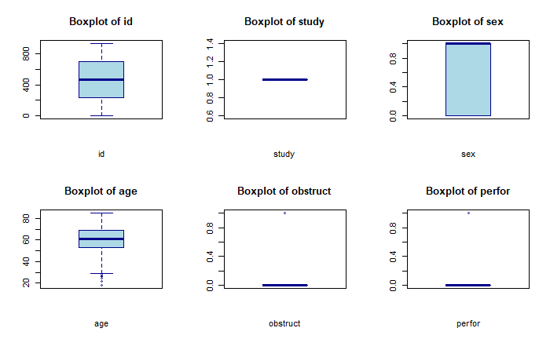

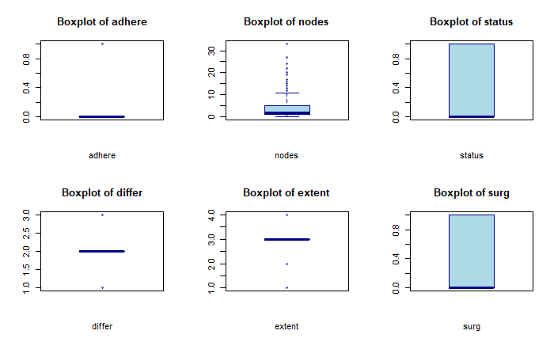

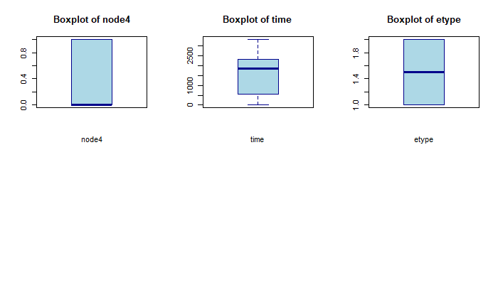

```r
# Save the table as an HTML file
save_kable(summary_table, file = "summary_table.html")

# Function to plot boxplots for all numeric columns
plot_boxplots <- function(data) {
  numeric_cols <- sapply(data, is.numeric)
  numeric_data <- data[, numeric_cols, drop = FALSE]

  # Optional: arrange multiple plots in a grid (2 rows, 3 columns)
  par(mfrow = c(2, 3))
  for (col in names(numeric_data)) {
    boxplot(
      numeric_data[[col]],
      main = paste("Boxplot of", col),
      xlab = col,
      col = "lightblue",
      border = "darkblue"
    )
  }
  # Reset the plotting area to a single panel
  par(mfrow = c(1, 1))
}

# Call the function
plot_boxplots(colon_data)
```

```r
# Check for missing values
colSums(is.na(colon_data))
```

```
      id    study       rx      sex      age obstruct   perfor   adhere    nodes   status   differ   extent     surg    node4     time    etype
       0        0        0        0        0        0        0        0       36        0       46        0        0        0        0        0
```

## Analysis of the Exploratory Results

Below is a structured analysis of your Step 2 exploratory findings. walk through the key takeaways from the summary statistics, missing values check, and boxplots.

### 1. Data Structure Recap

- **Observations**: 1,858 rows (each row can represent a patient event record).
- **Variables**: 16 columns (numeric and factor types).

#### Key Variables:

- **time**: Time in days until an event (recurrence or death) or censoring.
- **status**: Event occurrence indicator (1 = event, 0 = censored).
- **etype**: Event type (1 = recurrence, 2 = death).
- **rx**: Treatment group (3 levels: “Obs”, “Lev”, “Lev+5FU”).
- **nodes**: Number of positive lymph nodes (0–33).
- **differ**: Tumor differentiation (1 = well, 2 = moderate, 3 = poor).
- **sex**: Encoded as 0 (female) and 1 (male), though numeric in the dataset.
- **id**: Patient identifier, which is not directly useful in modeling.

Understanding each variable’s purpose helps in deciding how to handle them during modeling (e.g., which to include as covariates).

### 2. Missing Values

- **nodes**: 36 missing values.
- **differ**: 46 missing values.
- All other variables appear complete.

Missing data can bias results if not handled properly.

### 3. Numeric Variable Distributions and Outliers

From the boxplots: - **age**: Ranges from 18 to 85; a few younger outliers (below 30). - **nodes**: Heavily right-skewed. Some patients have a high count (above 10), and the maximum is 33. - **time**: Spans 8 to 3329 days (over 9 years). The median is around 1855 days (~5 years). - **sex, obstruct, perfor, adhere, status, surg, node4, etype**: Each is effectively binary or categorical (0/1 or 1/2), so boxplots show minimal variation. - **differ (1 to 3) and extent (1 to 4)**: Appear mostly around 2–3, with a few outliers at 1 and 4.

Right-skewed data (like nodes and time) may benefit from transformations (e.g., log-transform) if needed for certain models. Outliers might represent genuine clinical scenarios, boxplots confirm the presence of two distinct categories.

### 4. Factor Variables

- **rx**: Three treatment groups (“Obs”, “Lev”, “Lev+5FU”).
- **study**: Always 1 (no variation, so it’s not useful for analysis).

rx is already a factor, but sex might be converted to a factor to make it more intuitive (0 = Female, 1 = Male). Factor variables are crucial in survival models (like Cox regression) to compare hazard rates among groups. Unvarying variables (like study) do not contribute any information to the model.

### 5. Overall Observations

- **No Large-Scale Missingness**: Only nodes (36 NAs) and differ (46 NAs) need attention.
- **Potential Outliers**: nodes (high node counts), age (younger ages), and time (very short or very long survival).
- **Mostly Categorical/Binary Data**: Many columns are 0/1 or 1/2, which is common in medical datasets (presence/absence, yes/no).
- **Two Records per Patient**: Remember that each patient has two rows (one for recurrence, one for death), which will be important in modeling.

## Step 3: Data Preprocessing and Survival Setup

### 3.1 Convert Data Types

convert binary/categorical variables (sex, obstruct, perfor, adhere, node4, surg, differ, extent) into factors with meaningful labels. This makes the data more readable and suitable for modeling.

```r
# Convert sex: 0 = Female, 1 = Male
colon_data$sex <- factor(colon_data$sex,
                         levels = c(0, 1),
                         labels = c("Female", "Male"))

# Convert obstruct, perfor, adhere: 0 = No, 1 = Yes
colon_data$obstruct <- factor(colon_data$obstruct,
                              levels = c(0, 1),
                              labels = c("No", "Yes"))
colon_data$perfor <- factor(colon_data$perfor,
                            levels = c(0, 1),
                            labels = c("No", "Yes"))
colon_data$adhere <- factor(colon_data$adhere,
                            levels = c(0, 1),
                            labels = c("No", "Yes"))

# Convert node4: 0 = <=4 positive nodes, 1 = >4 positive nodes
colon_data$node4 <- factor(colon_data$node4,
                           levels = c(0, 1),
                           labels = c("<=4", ">4"))

# Convert surg: 0 = Short, 1 = Long
colon_data$surg <- factor(colon_data$surg,
                          levels = c(0, 1),
                          labels = c("Short", "Long"))

# Convert differ: 1 = Well, 2 = Moderate, 3 = Poor
colon_data$differ <- factor(colon_data$differ,
                            levels = c(1, 2, 3),
                            labels = c("Well", "Moderate", "Poor"))

# Convert extent: 1 = Submucosa, 2 = Muscle, 3 = Serosa, 4 = Contiguous structures
colon_data$extent <- factor(colon_data$extent,
                            levels = c(1, 2, 3, 4),
                            labels = c("Submucosa", "Muscle", "Serosa", "Contiguous"))
```

### 3.2 Handle Missing Data (Multiple Imputation)

use the mice package to impute missing values rather than eliminating rows. This is a more robust approach when dealing with relatively small amounts of missing data.

```r
### 3.2 Handle Missing Data

# 1. Install/load the 'mice' package if not present
if (!require("mice")) install.packages("mice", dependencies = TRUE)
library(mice)

# 2. Select columns relevant for imputation
#    (Include the variables with missing data + additional predictors)
impute_vars <- c("nodes", "differ", "age", "sex", "obstruct",
                 "perfor", "adhere", "extent", "node4", "time", "status")

impute_data <- colon_data[, impute_vars]

# 3. Check default methods mice will use
#    For factor variables, 'mice' often uses logistic or polyreg;
#    for numeric, it uses pmm (Predictive Mean Matching) by default.
methods <- make.method(impute_data)
methods
```

```
    nodes    differ       age       sex  obstruct    perfor    adhere    extent     node4      time    status
    "pmm" "polyreg"        ""        ""        ""        ""        ""        ""        ""        ""        ""
```

```r
# (Optional) You can manually specify methods, e.g.:
# methods["differ"] <- "polyreg"   # for a factor with >2 levels
# methods["nodes"]  <- "pmm"       # for numeric

# 4. Run multiple imputation
imp <- mice(data = impute_data,
            m = 5,            # number of imputed datasets
            method = methods, # or your customized methods
            maxit = 5,        # number of iterations
            seed = 123)       # for reproducibility
# 5. Choose one of the imputed sets (1 to 5) to create a completed dataset
completed_data <- complete(imp, 1)

# 6. Assign the imputed columns back to your main dataset
colon_data$nodes   <- completed_data$nodes
colon_data$differ  <- completed_data$differ
```

### 3.3 Outlier & Skewness Handling

nodes is heavily skewed. We can log-transform it if we want to treat it as a continuous covariate.

```r
### 3.3 Outlier & Skewness Handling

# Create a log-transformed version of 'nodes'
# Adding +1 avoids log(0)
colon_data$log_nodes <- log(colon_data$nodes + 1)


# Function to return a list with lower and upper bounds
get_iqr_bounds <- function(x) {
  Q1 <- quantile(x, 0.25, na.rm = TRUE)
  Q3 <- quantile(x, 0.75, na.rm = TRUE)
  IQR_val <- Q3 - Q1
  lower_bound <- Q1 - 1.5 * IQR_val
  upper_bound <- Q3 + 1.5 * IQR_val
  return(list(lower = lower_bound, upper = upper_bound))
}

# Let's apply it to 'age', 'time', and 'nodes'
vars_to_check <- c("age","nodes")
bounds_list <- lapply(vars_to_check, function(v) {
  get_iqr_bounds(colon_data[[v]])
})
names(bounds_list) <- vars_to_check

bounds_list
```

```
$age
$age$lower
25%
 29

$age$upper
75%
 93


$nodes
$nodes$lower
25%
 -5

$nodes$upper
75%
 11
```

```r
# This will print the lower/upper bound for each variable

### 3.3.2 Flag Outliers

for (v in vars_to_check) {
  lb <- bounds_list[[v]]$lower
  ub <- bounds_list[[v]]$upper
  outlier_col_name <- paste0("outlier_", v)

  colon_data[[outlier_col_name]] <- ifelse(colon_data[[v]] < lb |
                                           colon_data[[v]] > ub, 1, 0)
}

# Check how many outliers in each variable
table(colon_data$outlier_age)
```

```
   0    1
1842   16
```

```r
table(colon_data$outlier_time)
```

```
< table of extent 0 >
```

```r
table(colon_data$outlier_nodes)
```

```
   0    1
1777   81
```

```r
for (v in vars_to_check) {
  lb <- bounds_list[[v]]$lower
  ub <- bounds_list[[v]]$upper
  cap_col_name <- paste0(v, "_wins")

  # Winsorize the variable
  colon_data[[cap_col_name]] <- pmin(pmax(colon_data[[v]], lb), ub)
}
# Inspect results
summary(colon_data[, c("nodes","log_nodes","nodes_wins", "age_wins","age")])
```

```
     nodes          log_nodes        nodes_wins        age_wins          age
 Min.   : 0.000   Min.   :0.0000   Min.   : 0.000   Min.   :29.00   Min.   :18.00
 1st Qu.: 1.000   1st Qu.:0.6931   1st Qu.: 1.000   1st Qu.:53.00   1st Qu.:53.00
 Median : 2.000   Median :1.0986   Median : 2.000   Median :61.00   Median :61.00
 Mean   : 3.737   Mean   :1.3498   Mean   : 3.538   Mean   :59.79   Mean   :59.75
 3rd Qu.: 5.000   3rd Qu.:1.7918   3rd Qu.: 5.000   3rd Qu.:69.00   3rd Qu.:69.00
 Max.   :33.000   Max.   :3.5264   Max.   :11.000   Max.   :85.00   Max.   :85.00
```

## Summary of Data Preprocessing

### 1. Multiple Imputation (MICE)

- Created 5 imputed datasets for missing values in `nodes` and `differ`.
- Used one completed dataset (`complete(imp, 1)`) for exploration.
- **Key Point**: For final analysis, pool results across all imputations.

### 3. Capping & Log Transforms

- **Winsorizing**:
  - `age_wins`: Capped at 29 (min) and 85 (max).
  - `nodes_wins`: Capped at 11 (max).
- **Log Transforms**:
  - `log_nodes`: Range ≈ 0 to 3.53, reducing skewness.
- **Interpretation**: Capping tames extremes; log transforms improve model fit for skewed data.

## Define Censoring Variables

### Decide on Your Survival Endpoint

#### A. Single-Event Analysis (Any Event)

**Goal**: Treat either recurrence or death as the event. **Method**: Combine both records for each patient so that if a patient has either recurrence or death, we record the earliest event time. Censor if the patient does not experience any event.

#### B. Single-Event Analysis (Death Only)

**Goal**: Model time to death as the sole event. **Method**: Subset the data to rows where `etype == 2` (death). Censor if the patient has no death record.

#### C. Single-Event Analysis (Recurrence Only)

**Goal**: Model time to recurrence as the sole event. **Method**: Subset the data to rows where `etype == 1` (recurrence). Censor if the patient has no recurrence record.

#### D. Competing Risks Analysis

**Goal**: Distinguish between recurrence (`etype=1`) and death (`etype=2`) as competing events. **Method**: Use a competing risks framework (e.g., `cmprsk` or `mstate` package) rather than the standard `Surv()`.

### Approach A: Single-Event Analysis (Any Event)

Goal - Combine recurrence and death into one “event.” - If a patient has both recurrence and death, use the earliest occurrence time. - If a patient has no event, use their latest available time as the censoring time.

```r
library(dplyr)
library(survival)

# A) Any Event
colon_any_event <- colon_data %>%
  group_by(id) %>%
  summarize(
    # If the patient has at least one event (status == 1), take the earliest event time
    time = if (any(status == 1)) {
      min(time[status == 1])
    } else {
      # Otherwise, no event => censor at the maximum time
      max(time)
    },
    # Event indicator: 1 if any event, 0 if none
    status = if (any(status == 1)) 1 else 0
  ) %>%
  ungroup()

# Create a Surv object for "any event"
colon_any_event$surv_any <- Surv(colon_any_event$time, colon_any_event$status)

# Example usage:
# fit_any <- survfit(surv_any ~ 1, data = colon_any_event)
# summary(fit_any)
```

### Approach B: Single-Event Analysis (Death Only)

- Goal: Model time to death.
- Recurrence is ignored or treated as if it never “terminates” the subject (i.e., the patient can still die later).
- If no death occurs, censor at the maximum time.

```r
# B) Death Only
colon_death <- colon_data %>%
  group_by(id) %>%
  summarize(
    # Earliest time where status=1 and etype=2
    time = if (any(status == 1 & etype == 2)) {
      min(time[status == 1 & etype == 2])
    } else {
      max(time)
    },
    # Event indicator for death
    status = if (any(status == 1 & etype == 2)) 1 else 0
  ) %>%
  ungroup()

colon_death$surv_death <- Surv(colon_death$time, colon_death$status)

# Example usage:
# fit_death <- survfit(surv_death ~ 1, data = colon_death)
# summary(fit_death)
```

### Approach C: Single-Event Analysis (Recurrence Only)

- Goal: Model time to recurrence.
- Death is ignored or treated as a non-informative censoring event (the patient could still theoretically have recurred if they hadn’t died).
- If no recurrence, censor at the maximum time.

```r
# C) Recurrence Only
colon_recur <- colon_data %>%
  group_by(id) %>%
  summarize(
    # Earliest time where status=1 and etype=1
    time = if (any(status == 1 & etype == 1)) {
      min(time[status == 1 & etype == 1])
    } else {
      max(time)
    },
    # Event indicator for recurrence
    status = if (any(status == 1 & etype == 1)) 1 else 0
  ) %>%
  ungroup()

colon_recur$surv_recur <- Surv(colon_recur$time, colon_recur$status)

# Example usage:
# fit_recur <- survfit(surv_recur ~ 1, data = colon_recur)
# summary(fit_recur)
```

### Approach D: Competing Risks (Recurrence vs. Death)

- Goal: Treat recurrence (etype=1) and death (etype=2) as distinct, competing events.
- Once one event occurs, the other can’t happen (i.e., no second event).
- Use a specialized package like cmprsk or mstate.

```r
# install.packages("cmprsk") # if not installed
library(cmprsk)
```

```r
colon_cr <- colon_data %>%
  group_by(id) %>%
  summarize(
    # If there's any event, pick the earliest time
    time = if (any(status == 1)) {
      min(time[status == 1])
    } else {
      max(time)  # no event => censor at max time
    },
    # Determine which event happened first
    fstatus = case_when(
      # If earliest event was recurrence
      any(status == 1 & etype == 1 & time[status == 1 & etype == 1] == min(time[status == 1])) ~ 1,
      # If earliest event was death
      any(status == 1 & etype == 2 & time[status == 1 & etype == 2] == min(time[status == 1])) ~ 2,
      TRUE ~ 0  # no event
    )
  ) %>%
  ungroup()

# Merge 'rx' or other covariates so we can compare groups
colon_cr <- colon_cr %>%
  left_join(distinct(select(colon_data, id, rx)), by = "id")

# cencode = 0 indicates censored state
# group = colon_cr$rx to compare incidence curves by treatment group
cuminc_result <- cuminc(
  ftime = colon_cr$time,
  fstatus = colon_cr$fstatus,
  group = colon_cr$rx,
  cencode = 0
)

cuminc_result
```

```
Tests:
       stat        pv df
2 0.4696999 0.7906895  2
Estimates and Variances:
$est
                  500       1000       1500       2000       2500      3000
Obs 2     0.009370935 0.03162295 0.05099513 0.05818456 0.08503838 0.1612852
Lev 2     0.015186137 0.02674818 0.03310930 0.03982382 0.06601910 0.0660191
Lev+5FU 2 0.018229974 0.02776217 0.02776217 0.04954507 0.07369847 0.1017682

$var
                   500         1000         1500         2000         2500         3000
Obs 2     4.371639e-05 0.0001639398 0.0002808964 0.0003283445 0.0006671479 0.0063741644
Lev 2     5.883388e-05 0.0001241633 0.0001630095 0.0002058381 0.0005761043 0.0005761043
Lev+5FU 2 6.589893e-05 0.0001098380 0.0001098380 0.0002217415 0.0004097404 0.0011731944
```

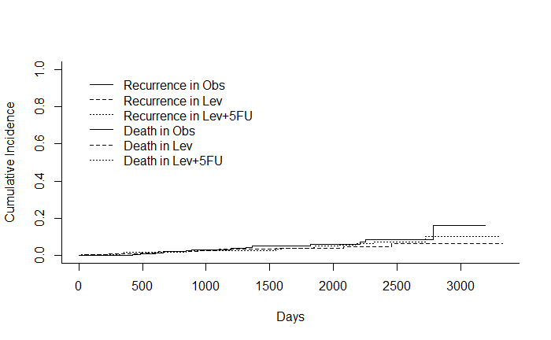

```r
# This prints cumulative incidence estimates for each event type (1 or 2),
# stratified by 'rx' if provided.

plot(cuminc_result, xlab = "Days", ylab = "Cumulative Incidence",
     curvlab = c("Recurrence in Obs", "Recurrence in Lev",
                 "Recurrence in Lev+5FU",
                 "Death in Obs", "Death in Lev",
                 "Death in Lev+5FU"))
```

```r
NA
NA
```

## Understanding the Output

### Interpretation & Conclusions

#### No Significant Group Difference for Death

- Gray’s test p-value = 0.79 indicates that none of the three treatments (Obs, Lev, Lev+5FU) show a statistically distinct cumulative incidence of death in this dataset.
- Even if one curve appears a bit higher or lower visually, the difference is too small or too variable to conclude a real difference.

#### Clinical Perspective

- If the research question was “Does Lev or Lev+5FU reduce the probability of death compared to Obs?”, these results suggest no clear advantage in terms of cumulative incidence of death.
- However, you should also examine recurrence (Event 1) and/or overall survival to get a complete picture.

## Step 4: Perform Descriptive Analysis

We will perform descriptive analysis by visualizing the distribution of survival times and covariates.

```r
# Summary of raw survival times
summary(colon_data$time)
```

```
   Min. 1st Qu.  Median    Mean 3rd Qu.    Max.
      8     566    1855    1538    2331    3329
```

```r
# How many patients had an event vs. censored
table(colon_data$status)
```

```
  0   1
938 920
```

```r
# Summaries of numeric variables
summary(colon_data$age)
```

```
   Min. 1st Qu.  Median    Mean 3rd Qu.    Max.
  18.00   53.00   61.00   59.75   69.00   85.00
```

```r
summary(colon_data$nodes)
```

```
   Min. 1st Qu.  Median    Mean 3rd Qu.    Max.
  0.000   1.000   2.000   3.737   5.000  33.000
```

```r
summary(colon_data$log_nodes)
```

```
   Min. 1st Qu.  Median    Mean 3rd Qu.    Max.
 0.0000  0.6931  1.0986  1.3498  1.7918  3.5264
```

```r
# Factor (Categorical) Covariates
# Treatment groups
table(colon_data$rx)
```

```
    Obs     Lev Lev+5FU
    630     620     608
```

```r
# Sex distribution
table(colon_data$sex)
```

```
Female   Male
   890    968
```

```r
# Tumor differentiation
table(colon_data$differ)
```

```
    Well Moderate     Poor
     191     1360      307
```

```r
# Extent of disease
table(colon_data$extent)
```

```
 Submucosa     Muscle     Serosa Contiguous
        42        212       1518         86
```

```r
# Compare a covariate to the event status
table(colon_data$rx, colon_data$status)
```

```
            0   1
  Obs     285 345
  Lev     287 333
  Lev+5FU 366 242
```

```r
table(colon_data$sex, colon_data$status)
```

```
           0   1
  Female 446 444
  Male   492 476
```

```r
# Summary Tables with dplyr or tableone
colon_data %>%
  summarize(
    N = n(),
    MedianTime = median(time, na.rm = TRUE),
    MeanTime = mean(time, na.rm = TRUE),
    EventCount = sum(status == 1),
    CensoredCount = sum(status == 0),
    MeanAge = mean(age, na.rm = TRUE),
    # Add more as needed
  )
```

| N | MedianTime | MeanTime | EventCount | CensoredCount | MeanAge |
| --- | --- | --- | --- | --- | --- |
| 1858 | 1855 | 1537.546 | 920 | 938 | 59.75457 |

```r
library(tableone)

vars <- c("time", "age", "nodes", "sex", "differ")
tab1 <- CreateTableOne(vars = vars, strata = "rx", data = colon_data)
print(tab1, showAllLevels = TRUE)
```

```
                   Stratified by rx
                    level    Obs              Lev              Lev+5FU          p      test
  n                              630              620              608
  time (mean (SD))           1440.61 (929.15) 1465.28 (961.73) 1711.68 (926.63) <0.001
  age (mean (SD))              59.45 (11.96)    60.11 (11.64)    59.70 (12.25)   0.616
  nodes (mean (SD))             3.80 (3.71)      3.78 (3.59)      3.62 (3.59)    0.616
  sex (%)           Female       298 (47.3)       266 (42.9)       326 (53.6)    0.001
                    Male         332 (52.7)       354 (57.1)       282 (46.4)
  differ (%)        Well          54 ( 8.6)        77 (12.4)        60 ( 9.9)    0.138
                    Moderate     471 (74.8)       451 (72.7)       438 (72.0)
                    Poor         105 (16.7)        92 (14.8)       110 (18.1)
```

## Overall Dataset Summary

### Total Observations (N): 1858

#### Events vs. Censored:

- **920 events** (status = 1)
- **938 censored** (status = 0)
- This is almost an even split (about 49.5% events).

#### Age

- **Median**: 61 years
- **Range**: 18 to 85 years
- **Mean**: around 59.75 years.

#### Tumor Differentiation (differ)

- **Well**: 191 patients
- **Moderate**: 1360 patients
- **Poor**: 307 patients
- Most tumors are moderately differentiated.

#### Extent of Disease (extent)

- **Submucosa**: 42
- **Muscle**: 212
- **Serosa**: 1518
- **Contiguous**: 86
- The majority (over 80%) are serosa involvement.

## By Treatment Group (rx)

We have three groups: Obs, Lev, and Lev+5FU. A stratified summary shows:

[output not shown]

### Key Observations

#### Nodes:

- Means range from 3.62 to 3.80; p-value = 0.616 shows no significant difference among groups.

#### Differentiation (differ):

- p-value = 0.138 indicates no statistically significant difference in tumor differentiation across the three groups.

## Event vs. Censoring by Group

From the tables:

- **Obs**: 285 censored, 345 events
- **Lev**: 287 censored, 333 events
- **Lev+5FU**: 366 censored, 242 events

### Interpretation:

- Lev+5FU shows more censored patients than events (366 vs. 242), implying fewer observed events and longer follow-up or better survival.
- Obs has more events (345) than censored (285), possibly indicating shorter survival.
- (Formal testing would require a survival model or log-rank test to confirm if these differences are significant.)

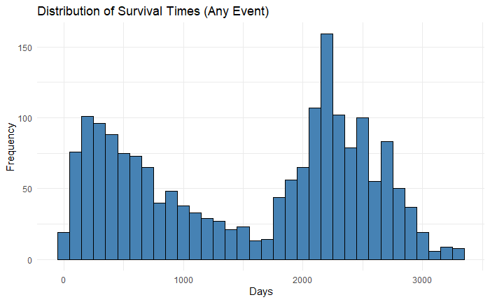

```r
##################################################
#  Load Necessary Packages
##################################################
suppressWarnings({
  if (!require("ggplot2")) install.packages("ggplot2", dependencies=TRUE)
  library(ggplot2)
})
##################################################
#  1. Histogram of Survival Time (Any Event)
##################################################
ggplot(colon_data, aes(x = time)) +
  geom_histogram(binwidth = 100, fill = "steelblue", color = "black") +
  labs(
    title = "Distribution of Survival Times (Any Event)",
    x = "Days",
    y = "Frequency"
  ) +
  theme_minimal()
```

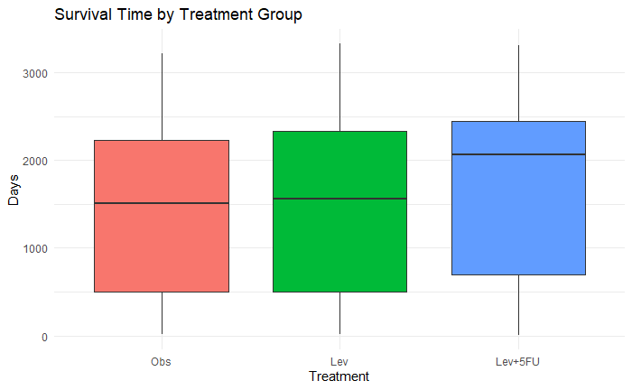

```r
##################################################
#  2. Boxplot of Survival Time by Treatment Group
##################################################
ggplot(colon_data, aes(x = rx, y = time, fill = rx)) +
  geom_boxplot() +
  labs(
    title = "Survival Time by Treatment Group",
    x = "Treatment",
    y = "Days"
  ) +
  theme_minimal() +
  theme(legend.position = "none")  # Hide redundant legend
```

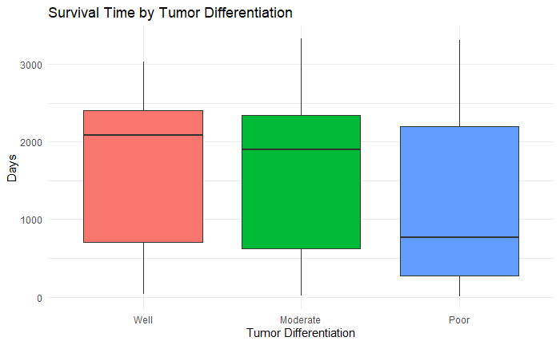

```r
##################################################
#  3. Boxplot of Survival Time by Tumor Differentiation
##################################################
ggplot(colon_data, aes(x = differ, y = time, fill = differ)) +
  geom_boxplot() +
  labs(
    title = "Survival Time by Tumor Differentiation",
    x = "Tumor Differentiation",
    y = "Days"
  ) +
  theme_minimal() +
  theme(legend.position = "none")
```

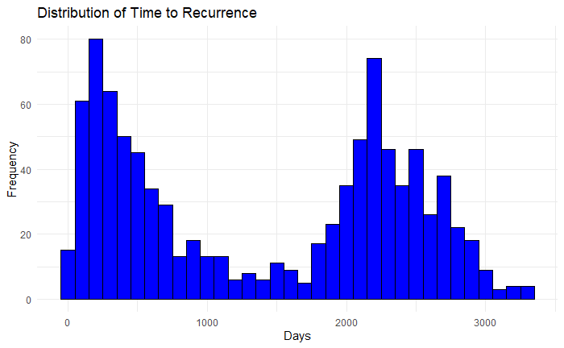

```r
##################################################
#  4. (Optional) Distribution of Time to Recurrence
##################################################
# Only run this if you have a 'colon_recur' dataset
# (subset for recurrence event).
ggplot(colon_recur, aes(x = time)) +
  geom_histogram(binwidth = 100, fill = "blue", color = "black") +
  labs(
    title = "Distribution of Time to Recurrence",
    x = "Days",
    y = "Frequency"
  ) +
  theme_minimal()
```

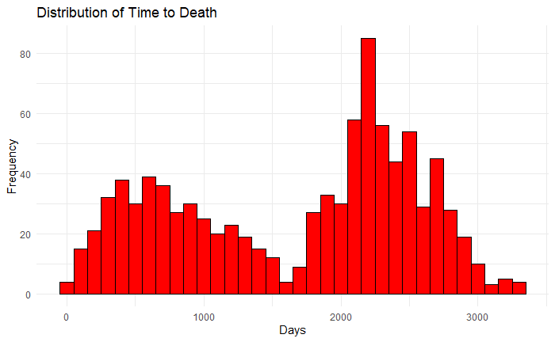

```r
##################################################
#  5. (Optional) Distribution of Time to Death
##################################################
# Only run this if you have a 'colon_death' dataset
# (subset for death event).
ggplot(colon_death, aes(x = time)) +
  geom_histogram(binwidth = 100, fill = "red", color = "black") +
  labs(
    title = "Distribution of Time to Death",
    x = "Days",
    y = "Frequency"
  ) +
  theme_minimal()
```

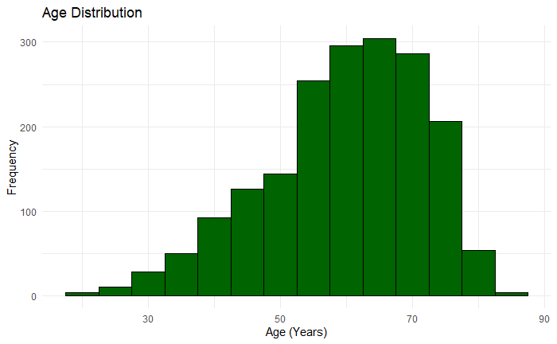

```r
##################################################
#  6. Histogram of Age Distribution
##################################################
ggplot(colon_data, aes(x = age)) +
  geom_histogram(binwidth = 5, fill = "darkgreen", color = "black") +
  labs(
    title = "Age Distribution",
    x = "Age (Years)",
    y = "Frequency"
  ) +
  theme_minimal()
```

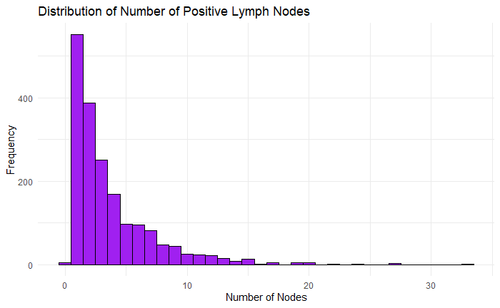

```r
##################################################
#  7. Distribution of Lymph Nodes
##################################################
ggplot(colon_data, aes(x = nodes)) +
  geom_histogram(binwidth = 1, fill = "purple", color = "black") +
  labs(
    title = "Distribution of Number of Positive Lymph Nodes",
    x = "Number of Nodes",
    y = "Frequency"
  ) +
  theme_minimal()
```

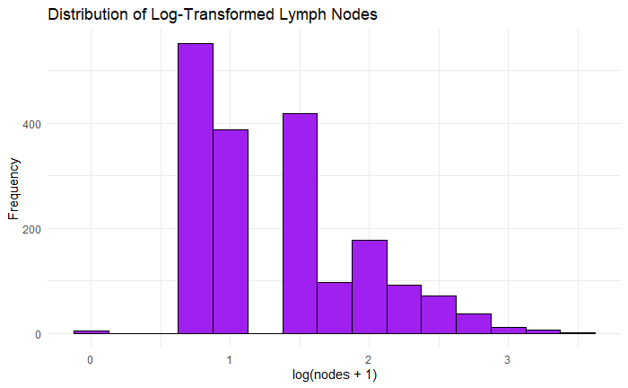

```r
ggplot(colon_data, aes(x = log_nodes)) +
  geom_histogram(binwidth = 0.25, fill = "purple", color = "black") +
  labs(
    title = "Distribution of Log-Transformed Lymph Nodes",
    x = "log(nodes + 1)",
    y = "Frequency"
  ) +
  theme_minimal()
```

```r
NA
NA
```

## Distribution of Number of Positive Lymph Nodes

- **Shape**: Heavily right-skewed; most patients have 0 to 5 positive nodes, and only a small fraction have >10.
- **Interpretation**: Lymph node involvement is typically low for many patients, but some have high node counts (up to ~30+). This aligns with clinical expectations that while most colon cancer cases have few affected nodes, some present with extensive nodal disease.

## Shape of the Distribution

### After Log-Transforming

- **Fewer Extreme Values**: The high end of the distribution has fewer extreme values.
- **Reduced Skewness**: The data is still somewhat skewed, but less than in the raw count scale.

### Values on the x-axis (log(nodes + 1))

- **log(nodes+1) = 0** → nodes = 0
- **log(nodes+1) = 1** → nodes ≈ 1.72
- **log(nodes+1) = 2** → nodes ≈ 6.39
- **log(nodes+1) = 3** → nodes ≈ 19.09
- **log(nodes+1) = 4** → nodes ≈ 53.60

#### Interpretation

- **Large Spike Around log(nodes+1) = 0–1**: Many patients have 0–2 positive nodes.
- **Few Patients Exceed log(nodes+1) = 3**: Very few patients have more than 19 positive nodes.

## Age Distribution

- **Shape**: Roughly bell-shaped (unimodal) with a peak around 60–70 years.
- **Range**: From ~20 to ~85, with a median ~61 (as noted in your summary stats).
- **Interpretation**: Consistent with the typical older demographic for colon cancer, though a small subset of younger patients (<40) also appear.

## Overall Observations & Next Steps

- **Highly Variable Survival Times**: Both for any event and specifically for recurrence or death. Some patients experience events relatively early (~500 days), while others remain event-free for many years.
- **Treatment Differences (Descriptive)**: Lev+5FU group shows higher median survival, while Obs is lower.
- **Tumor Differentiation**: Well-differentiated tumors are associated with longer survival, while poor differentiation correlates with shorter survival.

## Estimate survival functions using Kaplan-Meier curves

Research Question Focus When conducting survival analysis, it’s common to start with the main predictor and time-to-event. Here’s a structured approach:

Initial Analysis:

Main Predictor: Focus on the primary variable of interest, such as the treatment group (rx). Time-to-Event: Analyze the time until the event occurs (e.g., recurrence or death). Simpler Models:

Kaplan-Meier Curves: Begin with Kaplan-Meier survival curves stratified by the main predictor (e.g., treatment group). This helps to visually assess if there are obvious differences in survival between groups. Adding Covariates:

Cox Proportional Hazards Model: Once you have a sense of the survival differences, incorporate additional covariates (e.g., age, sex, nodes, obstruct) into a Cox model. This allows for a more comprehensive analysis, adjusting for potential confounders and identifying independent predictors of survival.

```r
#  If We already merged data into a single row per patient (Approach A)
# For "any event"
# Surv object:
colon_any_event$surv_any <- Surv(time = colon_any_event$time,
                                  event = colon_any_event$status)
```

```r
# Surv object with original data (assuming one row per patient)
colon_data$surv_obj <- Surv(time = colon_data$time, event = colon_data$status)
```

```r
# Using the Surv object in colon_data
fit_km_rx <- survfit(surv_obj ~ rx, data = colon_data)

# Print a summary of the fit
summary(fit_km_rx)
```

```
Call: survfit(formula = surv_obj ~ rx, data = colon_data)

                rx=Obs
 time n.risk n.event survival std.err lower 95% CI upper 95% CI
   20    630       1    0.998 0.00159        0.995        1.000
   36    629       1    0.997 0.00224        0.992        1.000
   43    628       1    0.995 0.00274        0.990        1.000
   45    627       1    0.994 0.00316        0.987        1.000
   59    626       1    0.992 0.00354        0.985        0.999
   72    625       1    0.990 0.00387        0.983        0.998
   77    624       1    0.989 0.00418        0.981        0.997
   79    623       1    0.987 0.00446        0.979        0.996
   80    622       2    0.984 0.00498        0.974        0.994
   85    620       1    0.983 0.00522        0.972        0.993
   86    619       1    0.981 0.00545        0.970        0.992
```

[output cut: 424 more lines]

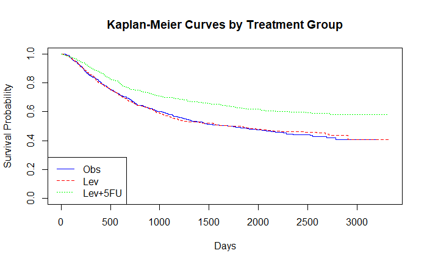

```r
plot(fit_km_rx,
     xlab = "Days",
     ylab = "Survival Probability",
     col = c("blue", "red", "green"),
     lty = 1:3,
     main = "Kaplan-Meier Curves by Treatment Group")

legend("bottomleft",
       legend = levels(colon_data$rx),
       col = c("blue", "red", "green"),
       lty = 1:3)
```

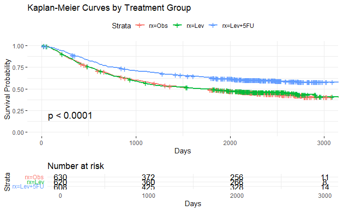

```r
library(survminer)
ggsurvplot(
  fit = fit_km_rx,
  data = colon_data,
  risk.table = TRUE,       # show number at risk table
  pval = TRUE,             # show p-value from log-rank test
  ggtheme = theme_minimal(),
  title = "Kaplan-Meier Curves by Treatment Group",
  xlab = "Days",
  ylab = "Survival Probability"
)
```

```r
logrank_test_rx <- survdiff(surv_obj ~ rx, data = colon_data)
logrank_test_rx
```

```
Call:
survdiff(formula = surv_obj ~ rx, data = colon_data)

             N Observed Expected (O-E)^2/E (O-E)^2/V
rx=Obs     630      345      299      7.01     10.40
rx=Lev     620      333      295      4.93      7.26
rx=Lev+5FU 608      242      326     21.61     33.54

 Chisq= 33.6  on 2 degrees of freedom, p= 5e-08
```

## Kaplan-Meier Curves by Treatment

### Survival Probabilities (from the survfit summary)

- For each time point, you see columns for survival, std.err, and 95% CI.
- At early times (like ~50 days), survival is ~0.99 or higher across groups.
- By later times (~3000 days), survival probabilities diverge, with Lev+5FU typically retaining higher survival.

### Interpretation

- Visually, Lev+5FU group experiences fewer (or later) events, while the Obs group experiences more (or earlier) events.
- This pattern suggests Lev+5FU might be more effective at delaying the event (recurrence or death).

## Log-Rank Test

- **Chi-square = 33.6 on 2 degrees of freedom, p = 5e-08 (~0.00000005)**
  - This is a highly significant result (< 0.0001), indicating that at least one survival curve differs from the others.

### From the table:

[output not shown]

### Interpretation

- The p-value is extremely small, so we can reject the null hypothesis that all three groups have the same survival function.
- In plain language: Treatment significantly affects time to event (the combined outcome).

## Practical Takeaways

- **Lev+5FU**: Appears to provide a survival advantage, while Obs is least effective.
- **Lev**: Is in between but closer to Obs, based on the shape of the curves and the number of events.

### Manual Pairwise Log-Rank Tests

```r
# Pair 1: Obs vs Lev
survdiff(Surv(time, status) ~ rx,
         data = colon_data,
         subset = (rx %in% c("Obs", "Lev")))
```

```
Call:
survdiff(formula = Surv(time, status) ~ rx, data = colon_data,
    subset = (rx %in% c("Obs", "Lev")))

         N Observed Expected (O-E)^2/E (O-E)^2/V
rx=Obs 630      345      341    0.0372     0.075
rx=Lev 620      333      337    0.0377     0.075

 Chisq= 0.1  on 1 degrees of freedom, p= 0.8
```

```r
# Pair 2: Obs vs Lev+5FU
survdiff(Surv(time, status) ~ rx,
         data = colon_data,
         subset = (rx %in% c("Obs", "Lev+5FU")))
```

```
Call:
survdiff(formula = Surv(time, status) ~ rx, data = colon_data,
    subset = (rx %in% c("Obs", "Lev+5FU")))

             N Observed Expected (O-E)^2/E (O-E)^2/V
rx=Obs     630      345      281      14.7      28.2
rx=Lev+5FU 608      242      306      13.5      28.2

 Chisq= 28.2  on 1 degrees of freedom, p= 1e-07
```

```r
# Pair 3: Lev vs Lev+5FU
survdiff(Surv(time, status) ~ rx,
         data = colon_data,
         subset = (rx %in% c("Lev", "Lev+5FU")))
```

```
Call:
survdiff(formula = Surv(time, status) ~ rx, data = colon_data,
    subset = (rx %in% c("Lev", "Lev+5FU")))

             N Observed Expected (O-E)^2/E (O-E)^2/V
rx=Lev     620      333      273      13.0      24.8
rx=Lev+5FU 608      242      302      11.8      24.8

 Chisq= 24.8  on 1 degrees of freedom, p= 6e-07
```

## Pairwise Comparisons of Treatment Groups

### Obs vs Lev

- **p = 0.8**: Suggests no statistical difference in survival curves between Observation alone and Levamisole (Lev).
- **Interpretation**: Visually or clinically, these two groups appear quite similar in how quickly events occur.

### Obs vs Lev+5FU

- **p = 1 × 10⁻⁷**: Indicates a highly significant difference.
- **Interpretation**: Lev+5FU outperforms Obs, implying better survival (fewer/farther events).

### Lev vs Lev+5FU

- **p = 6 × 10⁻⁷**: Also indicates a highly significant difference.
- **Interpretation**: Lev+5FU outperforms Lev, again suggesting better survival.

### Summary

- **Lev+5FU**: Significantly better than both Obs and Lev, suggesting it provides a survival advantage.
- **Obs and Lev**: Not significantly different from each other, indicating similar survival outcomes.

These results highlight the effectiveness of Lev+5FU in improving survival compared to the other treatment groups.

## Kaplan-Meier Curves (Time to Death)

```r
# 1) Summarize time/status for death
colon_death <- colon_data %>%
  group_by(id) %>%
  summarize(
    time = if (any(status == 1 & etype == 2)) {
      min(time[status == 1 & etype == 2])
    } else {
      max(time)
    },
    status = if (any(status == 1 & etype == 2)) 1 else 0
  ) %>%
  ungroup()

# 2) Merge 'rx' from 'colon_data'
colon_death <- colon_death %>%
  left_join(
    select(colon_data, id, rx),
    by = "id"
  ) %>%
  distinct(id, .keep_all = TRUE)

# Now 'colon_death' should have columns: id, time, status, rx, ...
str(colon_death)
```

```
tibble [929 × 4] (S3: tbl_df/tbl/data.frame)
 $ id    : num [1:929] 1 2 3 4 5 6 7 8 9 10 ...
 $ time  : num [1:929] 1521 3087 963 293 659 ...
 $ status: num [1:929] 1 0 1 1 1 1 1 0 0 0 ...
 $ rx    : Factor w/ 3 levels "Obs","Lev","Lev+5FU": 3 3 1 3 1 3 2 1 2 3 ...
```

```r
# Surv object for time to death
colon_death$surv_death <- Surv(time = colon_death$time,
                               event = colon_death$status)
```

```r
# Suppose you want to compare survival by rx (Obs, Lev, Lev+5FU)
fit_km_death <- survfit(surv_death ~ rx, data = colon_death)

# Print a summary
summary(fit_km_death)
```

```
Call: survfit(formula = surv_death ~ rx, data = colon_death)

                rx=Obs
 time n.risk n.event survival std.err lower 95% CI upper 95% CI
  113    315       1    0.997 0.00317        0.991        1.000
  125    314       1    0.994 0.00448        0.985        1.000
  145    313       1    0.990 0.00547        0.980        1.000
  164    312       1    0.987 0.00631        0.975        1.000
  166    311       1    0.984 0.00704        0.970        0.998
  187    310       1    0.981 0.00770        0.966        0.996
  201    309       1    0.978 0.00831        0.962        0.994
  208    308       1    0.975 0.00886        0.957        0.992
  215    307       1    0.971 0.00939        0.953        0.990
  218    306       1    0.968 0.00988        0.949        0.988
  238    305       1    0.965 0.01034        0.945        0.986
```

[output cut: 400 more lines]

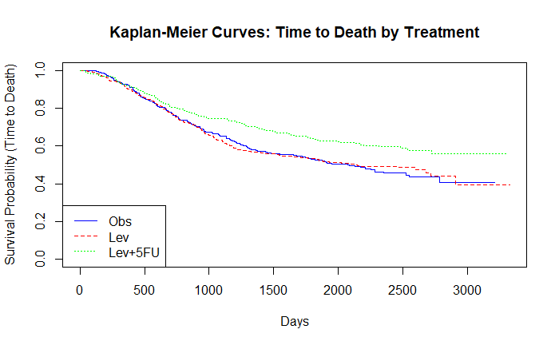

```r
plot(fit_km_death,
     xlab = "Days",
     ylab = "Survival Probability (Time to Death)",
     col = c("blue", "red", "green"),
     lty = 1:3,
     main = "Kaplan-Meier Curves: Time to Death by Treatment")

legend("bottomleft",
       legend = levels(colon_death$rx),
       col = c("blue", "red", "green"),
       lty = 1:3)
```

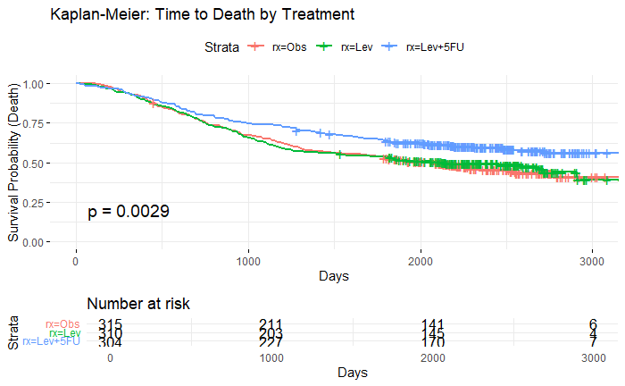

```r
ggsurvplot(
  fit = fit_km_death,
  data = colon_death,
  risk.table = TRUE,
  pval = TRUE,
  xlab = "Days",
  ylab = "Survival Probability (Death)",
  title = "Kaplan-Meier: Time to Death by Treatment",
  ggtheme = theme_minimal()
)
```

```r
logrank_death <- survdiff(surv_death ~ rx, data = colon_death)
logrank_death
```

```
Call:
survdiff(formula = surv_death ~ rx, data = colon_death)

             N Observed Expected (O-E)^2/E (O-E)^2/V
rx=Obs     315      168      148      2.58      3.85
rx=Lev     310      161      146      1.52      2.25
rx=Lev+5FU 304      123      157      7.55     11.62

 Chisq= 11.7  on 2 degrees of freedom, p= 0.003
```

```r
survdiff(Surv(time, status) ~ rx, data = colon_death,
         subset = (rx %in% c("Obs", "Lev")))
```

```
Call:
survdiff(formula = Surv(time, status) ~ rx, data = colon_death,
    subset = (rx %in% c("Obs", "Lev")))

         N Observed Expected (O-E)^2/E (O-E)^2/V
rx=Obs 315      168      166    0.0282     0.057
rx=Lev 310      161      163    0.0287     0.057

 Chisq= 0.1  on 1 degrees of freedom, p= 0.8
```

```r
survdiff(Surv(time, status) ~ rx, data = colon_death,
         subset = (rx %in% c("Obs", "Lev+5FU")))
```

```
Call:
survdiff(formula = Surv(time, status) ~ rx, data = colon_death,
    subset = (rx %in% c("Obs", "Lev+5FU")))

             N Observed Expected (O-E)^2/E (O-E)^2/V
rx=Obs     315      168      141      5.12      9.97
rx=Lev+5FU 304      123      150      4.82      9.97

 Chisq= 10  on 1 degrees of freedom, p= 0.002
```

```r
survdiff(Surv(time, status) ~ rx, data = colon_death,
         subset = (rx %in% c("Lev", "Lev+5FU")))
```

```
Call:
survdiff(formula = Surv(time, status) ~ rx, data = colon_death,
    subset = (rx %in% c("Lev", "Lev+5FU")))

             N Observed Expected (O-E)^2/E (O-E)^2/V
rx=Lev     310      161      137      4.24      8.21
rx=Lev+5FU 304      123      147      3.95      8.21

 Chisq= 8.2  on 1 degrees of freedom, p= 0.004
```

## Kaplan-Meier Curves (Time to Death)

### 1. Visual Ranking of Survival Curves

- **Lev+5FU (green/dotted)**: Remains the highest curve (best survival), meaning fewer patients die (or they die later).
- **Obs (blue/solid)** and **Lev (red/dashed)**: Are closer together. Sometimes one is slightly above the other, but they appear more similar than in the any-event analysis.

### Survival Probabilities Over Time

- **Early on (first 500–1000 days)**: Survival probabilities are quite high for all three groups.
- **By ~3000 days**: The curves have separated more clearly, with Lev+5FU maintaining the highest survival and Obs vs. Lev looking fairly close.

### 2. Log-Rank Test for Time to Death

- **Chi-square = 11.7, p = 0.003**: Indicates a statistically significant difference in time to death among the three groups.

#### Interpretation of Observed vs. Expected:

- **Obs**: 168 deaths observed vs. 148 expected, indicating more deaths than expected under a null (no-difference) scenario.
- **Lev**: Also has more observed than expected.
- **Lev+5FU**: Presumably has fewer observed than expected, aligning with better survival.

### 3. Comparison with “Any Event” Results

- **Any Event Analysis**: Had an extremely low p-value (~10⁻⁷) because Lev+5FU was drastically better for recurrence and death combined.
- **Time to Death**: Yields p = 0.003—still significant but less extreme.
- **Implication**: The difference among treatments is still real for death alone, but the magnitude of separation is somewhat smaller than in the any-event scenario. This suggests Lev+5FU provides a strong advantage particularly for recurrence prevention, though it also improves overall survival compared to the others.

### 4. Do Obs and Lev Differ?

- The log-rank test is global, so we only know that at least one pair differs.
- **Visually**: Obs and Lev appear close. You can do pairwise tests (subsetting to (Obs, Lev) only) to see if that difference is statistically significant.
- **If the p-value is large**: It means Obs vs. Lev are not significantly different in terms of time to death.

## Kaplan-Meier Curves (Time to Recurrence)

```r
# Step 1: Summarize time/status for recurrence
colon_recur <- colon_data %>%
  group_by(id) %>%
  summarize(
    # Earliest time if (status=1 & etype=1), otherwise max time
    time = if (any(status == 1 & etype == 1)) {
      min(time[status == 1 & etype == 1])
    } else {
      max(time)
    },
    # Recurrence indicator: 1 if event occurred, else 0
    status = if (any(status == 1 & etype == 1)) 1 else 0
  ) %>%
  ungroup()

# Step 2: Merge `rx` from the original data
colon_recur <- colon_recur %>%
  left_join(
    select(colon_data, id, rx),
    by = "id"
  ) %>%
  distinct(id, .keep_all = TRUE)

# Check structure
str(colon_recur)
```

```
tibble [929 × 4] (S3: tbl_df/tbl/data.frame)
 $ id    : num [1:929] 1 2 3 4 5 6 7 8 9 10 ...
 $ time  : num [1:929] 968 3087 542 245 523 ...
 $ status: num [1:929] 1 0 1 1 1 1 1 0 0 0 ...
 $ rx    : Factor w/ 3 levels "Obs","Lev","Lev+5FU": 3 3 1 3 1 3 2 1 2 3 ...
```

```r
head(colon_recur)
```

| id | time | status | rx |
| --- | --- | --- | --- |
| 1 | 968 | 1 | Lev+5FU |
| 2 | 3087 | 0 | Lev+5FU |
| 3 | 542 | 1 | Obs |
| 4 | 245 | 1 | Lev+5FU |
| 5 | 523 | 1 | Obs |
| 6 | 904 | 1 | Lev+5FU |

```r
NA
```

```r
# Create a Surv object for time to recurrence
colon_recur$surv_recur <- Surv(time = colon_recur$time,
                               event = colon_recur$status)
```

```r
fit_km_recur <- survfit(surv_recur ~ rx, data = colon_recur)

# View a textual summary of survival estimates
summary(fit_km_recur)
```

```
Call: survfit(formula = surv_recur ~ rx, data = colon_recur)

                rx=Obs
 time n.risk n.event survival std.err lower 95% CI upper 95% CI
   20    315       1    0.997 0.00317        0.991        1.000
   36    314       1    0.994 0.00448        0.985        1.000
   43    313       1    0.990 0.00547        0.980        1.000
   45    312       1    0.987 0.00631        0.975        1.000
   59    311       1    0.984 0.00704        0.970        0.998
   72    310       1    0.981 0.00770        0.966        0.996
   77    309       1    0.978 0.00831        0.962        0.994
   79    308       1    0.975 0.00886        0.957        0.992
   80    307       2    0.968 0.00988        0.949        0.988
   85    305       1    0.965 0.01034        0.945        0.986
   86    304       1    0.962 0.01079        0.941        0.983
```

[output cut: 397 more lines]

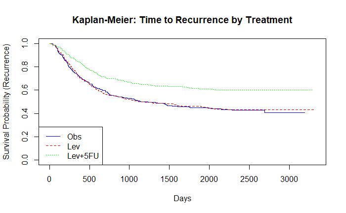

```r
plot(fit_km_recur,
     xlab = "Days",
     ylab = "Survival Probability (Recurrence)",
     col = c("blue", "red", "green"),
     lty = 1:3,
     main = "Kaplan-Meier: Time to Recurrence by Treatment")

legend("bottomleft",
       legend = levels(colon_recur$rx),
       col = c("blue", "red", "green"),
       lty = 1:3)
```

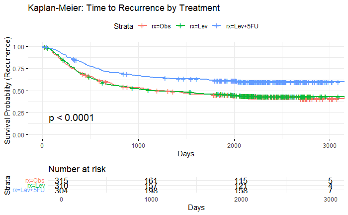

```r
ggsurvplot(
  fit = fit_km_recur,
  data = colon_recur,
  risk.table = TRUE,
  pval = TRUE,  # displays log-rank p-value
  xlab = "Days",
  ylab = "Survival Probability (Recurrence)",
  title = "Kaplan-Meier: Time to Recurrence by Treatment",
  ggtheme = theme_minimal()
)
```

```r
logrank_recur <- survdiff(surv_recur ~ rx, data = colon_recur)
logrank_recur
```

```
Call:
survdiff(formula = surv_recur ~ rx, data = colon_recur)

             N Observed Expected (O-E)^2/E (O-E)^2/V
rx=Obs     315      177      151      4.62      6.82
rx=Lev     310      172      149      3.69      5.41
rx=Lev+5FU 304      119      169     14.69     23.04

 Chisq= 23.1  on 2 degrees of freedom, p= 1e-05
```

```r
# Obs vs Lev
survdiff(Surv(time, status) ~ rx, data = colon_recur,
         subset = (rx %in% c("Obs", "Lev")))
```

```
Call:
survdiff(formula = Surv(time, status) ~ rx, data = colon_recur,
    subset = (rx %in% c("Obs", "Lev")))

         N Observed Expected (O-E)^2/E (O-E)^2/V
rx=Obs 315      177      176    0.0112    0.0226
rx=Lev 310      172      173    0.0114    0.0226

 Chisq= 0  on 1 degrees of freedom, p= 0.9
```

```r
# Obs vs Lev+5FU
survdiff(Surv(time, status) ~ rx, data = colon_recur,
         subset = (rx %in% c("Obs", "Lev+5FU")))
```

```
Call:
survdiff(formula = Surv(time, status) ~ rx, data = colon_recur,
    subset = (rx %in% c("Obs", "Lev+5FU")))

             N Observed Expected (O-E)^2/E (O-E)^2/V
rx=Obs     315      177      140     10.05      19.1
rx=Lev+5FU 304      119      156      8.96      19.1

 Chisq= 19.1  on 1 degrees of freedom, p= 1e-05
```

```r
# Lev vs Lev+5FU
survdiff(Surv(time, status) ~ rx, data = colon_recur,
         subset = (rx %in% c("Lev", "Lev+5FU")))
```

```
Call:
survdiff(formula = Surv(time, status) ~ rx, data = colon_recur,
    subset = (rx %in% c("Lev", "Lev+5FU")))

             N Observed Expected (O-E)^2/E (O-E)^2/V
rx=Lev     310      172      136      9.40      17.7
rx=Lev+5FU 304      119      155      8.27      17.7

 Chisq= 17.7  on 1 degrees of freedom, p= 3e-05
```

## Kaplan-Meier Curves (Time to Recurrence)

### 1. Visual Ranking

- **Lev+5FU (green/dotted)**: Shows the highest curve, meaning fewer patients recurred (or they recurred later).
- **Obs (blue/solid)** and **Lev (red/dashed)**: Appear lower, indicating earlier or more frequent recurrences.

### Interpretation

- **Lev+5FU**: Appears to be most effective at delaying or preventing recurrence.
- **Obs vs. Lev**: Are closer to each other, though you’d need pairwise tests to see if that difference is significant.

## Log-Rank Test for Time to Recurrence

- **Chi-Square = 23.1, p = 1e-05 (~0.00001)**
  - This is highly significant, indicating that at least one group’s recurrence-free survival differs from the others.

### Observed vs. Expected

- **Obs**: 177 recurrences observed vs. 151 expected → more recurrences than expected (worse outcome).
- **Lev**: 172 vs. 149 → also more recurrences than expected (worse).
- **Lev+5FU**: 119 vs. 169 → many fewer recurrences than expected (better).

### Interpretation

- The large difference is primarily driven by Lev+5FU performing significantly better (far fewer recurrences than expected).
- Obs and Lev have higher observed recurrences than expected, consistent with worse recurrence-free survival.

## Clinical/Practical Meaning

- **Lev+5FU**: Strong evidence it reduces recurrence compared to the other two treatments.
- **Obs vs. Lev**: The global log-rank test can’t tell you if they differ significantly from each other; you’d do pairwise tests (e.g., subsetting `rx %in% c("Obs", "Lev")`) to confirm.

## Pairwise Log-Rank Results

we ran three separate `survdiff` commands with subset to isolate each pair of groups:

### Obs vs Lev+5FU

- **χ² = 19.1, p = 1 × 10⁻⁵**
  - Highly significant difference: Lev+5FU is better (fewer recurrences).

### Lev vs Lev+5FU

- **χ² = 17.7, p = 3 × 10⁻⁵**
  - Highly significant difference: Lev+5FU is better than Lev.

## Interpretation

- **Obs vs Lev**:
  - **p = 0.9**: They do not differ significantly in terms of time to recurrence.
  - **Practical terms**: Levamisole alone does not provide a statistically significant benefit over observation for preventing recurrence.
- **Obs vs Lev+5FU**:
  - **p = 1e-05**: Strong evidence that Lev+5FU significantly reduces recurrence compared to observation alone.
- **Lev vs Lev+5FU**:
  - **p = 3e-05**: Also highly significant; Lev+5FU is much better than Lev alone at preventing recurrence.

### Overall Pattern

- **Lev+5FU**: Stands out as the only regimen that significantly delays or reduces recurrence.
- **Obs and Lev**: Are indistinguishable in this dataset for recurrence outcomes (i.e., no significant difference).

## Clinical/Practical Meaning

- **Lev+5FU**: Is clearly the optimal regimen for preventing recurrence.
- **Lev alone**: Does not appear to outperform Obs for recurrence-free survival.
- These findings confirm the global test result (p < 0.0001) was driven by Lev+5FU being significantly superior to both other arms.

## Cox Proportional Hazards Modeling

## Time to Any Event

### What It Does

- Combines recurrence and death into a single outcome.
- If a patient has either event, they’re considered to have “failed” at that time.

### Pros

- Simple summary of overall treatment failure (recurrence or death).
- Captures the earliest time a patient experiences any negative outcome.

### Cons

- No distinction between recurrence and death; you lose details about which event happened.
- If you care about overall survival specifically, or recurrence specifically, combining them can blur those details.

### When to Choose It

- We want a broad measure of “treatment failure,” and either recurrence or death is equally critical as an endpoint.
- Ideal if your research question is: “Does this treatment reduce the chance of any negative event (recurrence or death)?”

## Time to Death (Overall Survival)

### What It Does

- Only death counts as an event.
- Recurrence is ignored or treated as censored (the patient is still alive and at risk of eventually dying).

### Pros

- Clinically straightforward if your main endpoint is overall survival.
- Often the gold standard in many oncology trials: does the treatment prolong life?

### Cons

- Doesn’t capture recurrence patterns, which can be clinically important.
- A patient could recur early but still live for many years, and you’d miss that early recurrence in a time-to-death analysis.

### When to Choose It

- our primary question is about mortality: “Does the treatment reduce the risk of death?”
- Overall survival is often used in regulatory approvals and major clinical endpoints.

## Time to Recurrence

### What It Does

- Recurrence is the event; death is treated as censored (the patient is no longer at risk of recurrence if they die first).

### Pros

- Lets you focus on disease progression.
- Particularly important if your key question is about recurrence-free survival or relapse rates.

### Cons

- If patients die before recurrence, they’re censored, which can introduce bias if death is related to the same disease process.
- Does not capture overall survival. A treatment might reduce recurrence but not necessarily extend life (or vice versa).

### When to Choose It

- We care about tumor relapse specifically: “Does the treatment delay or prevent the return of cancer?”
- Recurrence is a clinically important endpoint (e.g., new metastatic lesions).

we choose the first approach !

## Select Covariates (with Reasons)

### 2.1 Commonly Included Predictors in Colon Cancer

#### rx (Treatment)

- **Reason**: Primary variable of interest. You want to see how each treatment arm (Obs, Lev, Lev+5FU) affects survival.

#### age (Numeric)

- **Reason**: Age is a universal risk factor; older patients often have worse outcomes.

#### sex (Male/Female)

- **Reason**: Sometimes survival differs by sex in colon cancer, though not always strongly.

#### nodes (Number of positive lymph nodes)

- **Reason**: Very strong prognostic factor in colon cancer. Often right-skewed, so consider log transform if needed.

#### differ (Tumor differentiation: Well, Moderate, Poor)

- **Reason**: Histological grade can strongly impact prognosis.

#### extent (Extent of local spread: Submucosa, Muscle, Serosa, Contiguous)

- **Reason**: Deeper invasion often means higher risk.

### 2.2 Optional or Secondary Predictors

#### obstruct, perfor, adhere (0/1)

- **Reason**: May indicate more complicated surgeries or advanced local disease. Sometimes less commonly included, but can be tested.

#### surg (Short vs. Long interval from surgery to registration)

- **Reason**: Might matter for follow-up patterns.

#### node4 (>4 positive nodes)

- **Reason**: A simpler, binary version of nodes. But if you already have the numeric nodes, node4 can be redundant.

### covariate list:

```r
# Example covariates
vars <- c("rx", "sex", "age", "log_nodes", "differ", "extent",
          "obstruct", "perfor", "adhere", "surg")
```

### Create the Surv Object

```r
##################################################
# 1. Load Packages
##################################################
# install.packages(c("dplyr", "survival"))
library(dplyr)
library(survival)

##################################################
# 2. Summarize to Create "colon_any_event"
#    One Row per Patient, Earliest Event Time
##################################################
colon_any_event <- colon_data %>%
  group_by(id) %>%
  summarize(
    # If a patient has any event (status == 1),
    # take the earliest time of that event.
    # Otherwise, if no event, use max time (censored).
    time = if (any(status == 1)) {
      min(time[status == 1])
    } else {
      max(time)
    },
    status = if (any(status == 1)) 1 else 0
  ) %>%
  ungroup()

##################################################
# 3. Left Join Covariates from Original Data
##################################################
# Select the covariates you want to keep:
# e.g., rx, age, sex, nodes, differ, extent, obstruct, perfor, adhere, surg
colon_any_event <- colon_any_event %>%
  left_join(
    select(colon_data,
           id, rx, age, sex, log_nodes, nodes, differ, extent,
           obstruct, perfor, adhere, surg),
    by = "id"
  ) %>%
  # If 'colon_data' had multiple rows per id,
  # distinct() ensures we keep only one row per patient
  distinct(id, .keep_all = TRUE)

# Check structure to confirm covariates are present
str(colon_any_event)
```

```
tibble [929 × 14] (S3: tbl_df/tbl/data.frame)
 $ id       : num [1:929] 1 2 3 4 5 6 7 8 9 10 ...
 $ time     : num [1:929] 968 3087 542 245 523 ...
 $ status   : num [1:929] 1 0 1 1 1 1 1 0 0 0 ...
 $ rx       : Factor w/ 3 levels "Obs","Lev","Lev+5FU": 3 3 1 3 1 3 2 1 2 3 ...
 $ age      : num [1:929] 43 63 71 66 69 57 77 54 46 68 ...
 $ sex      : Factor w/ 2 levels "Female","Male": 2 2 1 1 2 1 2 2 2 1 ...
 $ log_nodes: num [1:929] 1.792 0.693 2.079 1.946 3.135 ...
 $ nodes    : num [1:929] 5 1 7 6 22 9 5 1 2 1 ...
 $ differ   : Factor w/ 3 levels "Well","Moderate",..: 2 2 2 2 2 2 2 2 2 2 ...
 $ extent   : Factor w/ 4 levels "Submucosa","Muscle",..: 3 3 2 3 3 3 3 3 3 3 ...
 $ obstruct : Factor w/ 2 levels "No","Yes": 1 1 1 2 1 1 1 1 1 1 ...
 $ perfor   : Factor w/ 2 levels "No","Yes": 1 1 1 1 1 1 1 1 1 1 ...
 $ adhere   : Factor w/ 2 levels "No","Yes": 1 1 2 1 1 1 1 1 2 1 ...
 $ surg     : Factor w/ 2 levels "Short","Long": 1 1 1 2 2 1 2 1 1 2 ...
```

```r
head(colon_any_event)
```

| id | time | status | rx | age | sex | log_nodes | nodes | differ | extent | obstruct | perfor | adhere | surg |
| --- | --- | --- | --- | --- | --- | --- | --- | --- | --- | --- | --- | --- | --- |
| 1 | 968 | 1 | Lev+5FU | 43 | Male | 1.7917595 | 5 | Moderate | Serosa | No | No | No | Short |
| 2 | 3087 | 0 | Lev+5FU | 63 | Male | 0.6931472 | 1 | Moderate | Serosa | No | No | No | Short |
| 3 | 542 | 1 | Obs | 71 | Female | 2.0794415 | 7 | Moderate | Muscle | No | No | Yes | Short |
| 4 | 245 | 1 | Lev+5FU | 66 | Female | 1.9459101 | 6 | Moderate | Serosa | Yes | No | No | Long |
| 5 | 523 | 1 | Obs | 69 | Male | 3.1354942 | 22 | Moderate | Serosa | No | No | No | Long |
| 6 | 904 | 1 | Lev+5FU | 57 | Female | 2.3025851 | 9 | Moderate | Serosa | No | No | No | Short |

```r
##################################################
# 4. Create the Surv Object (Time to Any Event)
##################################################
colon_any_event$surv_any <- Surv(colon_any_event$time,
                                 colon_any_event$status)
```

### Univariable Cox Models in a Loop

```r
# Function to run univ Cox and extract tidy results
univ_results <- lapply(vars, function(v) {
  # Build a formula like: Surv(time, status) ~ var
  form <- as.formula(paste("surv_any ~", v))

  # Fit univariable Cox model
  fit <- coxph(form, data = colon_any_event)

  # Tidy results with broom
  res <- tidy(fit, conf.int = TRUE) %>%
    mutate(variable = v)  # keep track of which var
  return(res)
})

# Combine into one data frame
univ_results_df <- do.call(rbind, univ_results)

# Add columns for Hazard Ratio (HR) and 95% CI
univ_results_df <- univ_results_df %>%
  mutate(HR = exp(estimate),
         HR_lower = exp(conf.low),
         HR_upper = exp(conf.high))
```

### Visualize Univariable Results with ggplot2

```r
# Print table of univ results
print(univ_results_df)
```

| term | estimate | std.error | statistic | p.value | conf.low | conf.high | variable | HR | HR_lower | HR_upper |
| --- | --- | --- | --- | --- | --- | --- | --- | --- | --- | --- |
| rxLev | -0.032080625 | 0.103729093 | -0.3092732 | 7.571137e-01 | -0.235385912 | 0.17122466 | rx | 0.9684285 | 0.7902658 | 1.1867573 |
| rxLev+5FU | -0.473196855 | 0.112909327 | -4.1909457 | 2.777942e-05 | -0.694495069 | -0.25189864 | rx | 0.6230074 | 0.4993265 | 0.7773235 |
| sexMale | -0.052485147 | 0.088992070 | -0.5897733 | 5.553426e-01 | -0.226906399 | 0.12193611 | sex | 0.9488684 | 0.7969954 | 1.1296819 |
| age | -0.001796954 | 0.003799526 | -0.4729415 | 6.362549e-01 | -0.009243888 | 0.00564998 | age | 0.9982047 | 0.9907987 | 1.0056660 |
| log_nodes | 0.690474624 | 0.069477422 | 9.9381152 | 2.841526e-23 | 0.554301379 | 0.82664787 | log_nodes | 1.9946620 | 1.7407245 | 2.2856441 |
| differModerate | 0.132404400 | 0.156449317 | 0.8463086 | 3.973806e-01 | -0.174230627 | 0.43903943 | differ | 1.1415699 | 0.8401031 | 1.5512164 |
| differPoor | 0.540748143 | 0.180027468 | 3.0036980 | 2.667199e-03 | 0.187900789 | 0.89359550 | differ | 1.7172912 | 1.2067138 | 2.4439009 |
| extentMuscle | 0.294220099 | 0.438583423 | 0.6708418 | 5.023213e-01 | -0.565387613 | 1.15382781 | extent | 1.3420793 | 0.5681399 | 3.1703050 |
| extentSerosa | 0.906666840 | 0.411226066 | 2.2047893 | 2.746888e-02 | 0.100678561 | 1.71265512 | extent | 2.4760557 | 1.1059211 | 5.5436610 |
| extentContiguous | 1.539625981 | 0.444206138 | 3.4660169 | 5.282301e-04 | 0.668997949 | 2.41025401 | extent | 4.6628460 | 1.9522801 | 11.1367897 |

[output cut: 4 more lines]

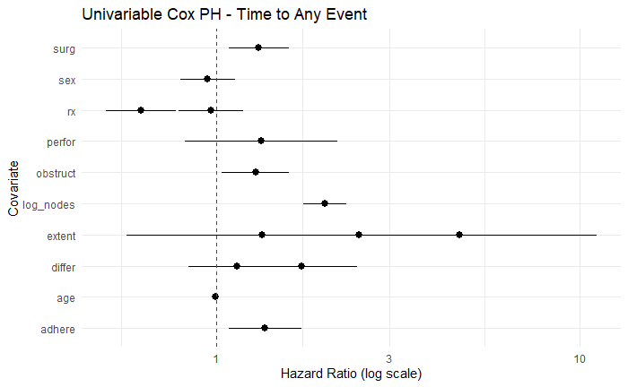

```r
# Forest plot with ggplot2
ggplot(univ_results_df, aes(x = variable,
                            y = HR,
                            ymin = HR_lower,
                            ymax = HR_upper)) +
  geom_pointrange() +
  geom_hline(yintercept = 1, linetype = 2, color = "red") +
  coord_flip() +
  scale_y_log10() +
  labs(
    x = "Covariate",
    y = "Hazard Ratio (log scale)",
    title = "Univariable Cox PH - Time to Any Event"
  ) +
  theme_minimal()
```

## Univariate Analysis Findings

### Interpretation

- **log_nodes**: Stands out as a strong predictor; more nodes → higher hazard.
- **rxLev+5FU**: Consistently shows hazard < 1, meaning improved survival relative to rxObs.

### Code to Filter Significant Variables

```r
# Suppose your univ results are in univ_results_df
sig_vars <- univ_results_df %>%
  filter(p.value < 0.05) %>%
  pull(variable)

sig_vars
```

```
[1] "rx"        "log_nodes" "differ"    "extent"    "extent"    "obstruct"  "adhere"    "surg"
```

### Build the Initial Multivariable Cox Model

```r
# including "rx"       "log_nodes"    "differ"   "extent"   "extent"   "obstruct" "adhere"   "surg"
cox_model <- coxph(
  Surv(time, status) ~ rx + obstruct + log_nodes + differ + extent + adhere + surg,
  data = colon_any_event
)
summary(cox_model)
```

```
Call:
coxph(formula = Surv(time, status) ~ rx + obstruct + log_nodes +
    differ + extent + adhere + surg, data = colon_any_event)

  n= 929, number of events= 506

                     coef exp(coef) se(coef)      z Pr(>|z|)
rxLev            -0.05076   0.95051  0.10463 -0.485  0.62760
rxLev+5FU        -0.48112   0.61809  0.11363 -4.234 2.29e-05 ***
obstructYes       0.21000   1.23368  0.10950  1.918  0.05513 .
log_nodes         0.64920   1.91402  0.07047  9.213  < 2e-16 ***
differModerate    0.01230   1.01238  0.15810  0.078  0.93798
differPoor        0.30329   1.35430  0.18410  1.647  0.09947 .
extentMuscle      0.05354   1.05500  0.44028  0.122  0.90321
extentSerosa      0.52862   1.69660  0.41436  1.276  0.20204
extentContiguous  1.05941   2.88467  0.45077  2.350  0.01876 *
adhereYes         0.18430   1.20237  0.12147  1.517  0.12923
surgLong          0.26847   1.30796  0.09718  2.763  0.00573 **
---
Signif. codes:  0 ‘***’ 0.001 ‘**’ 0.01 ‘*’ 0.05 ‘.’ 0.1 ‘ ’ 1

                 exp(coef) exp(-coef) lower .95 upper .95
rxLev               0.9505     1.0521    0.7743    1.1669
rxLev+5FU           0.6181     1.6179    0.4947    0.7723
obstructYes         1.2337     0.8106    0.9954    1.5290
log_nodes           1.9140     0.5225    1.6671    2.1975
differModerate      1.0124     0.9878    0.7426    1.3801
differPoor          1.3543     0.7384    0.9441    1.9428
extentMuscle        1.0550     0.9479    0.4451    2.5005
extentSerosa        1.6966     0.5894    0.7531    3.8219
extentContiguous    2.8847     0.3467    1.1923    6.9790
adhereYes           1.2024     0.8317    0.9476    1.5256
surgLong            1.3080     0.7646    1.0811    1.5824

Concordance= 0.672  (se = 0.012 )
Likelihood ratio test= 157.5  on 11 df,   p=<2e-16
Wald test            = 162.6  on 11 df,   p=<2e-16
Score (logrank) test = 168.9  on 11 df,   p=<2e-16
```

## Building the Multivariable Cox Model

### Combined Covariates:

- **rx** (main treatment factor)
- **log_nodes** (since it’s strongly significant)
- **obstruct**, **differ**, **extent**, **adhere**, **surg** (some are borderline or clinically relevant)

### Significant Variables (p < 0.05):

- **rxLev+5FU**: HR ≈ 0.62 → ~38% reduction in hazard vs. rxObs.
- **log_nodes**: HR ≈ 1.91 → Each log-unit increase in nodes nearly doubles the hazard.
- **extentContiguous**: HR ≈ 2.88 → Markedly higher hazard for contiguous spread vs. baseline category (likely Submucosa or whichever is reference).
- **surgLong**: HR ≈ 1.31 → “Long” interval from surgery to registration is associated with ~31% higher hazard.

### Borderline:

- **obstructYes**: p ~ 0.055.
- **differPoor**: p ~ 0.10.

### Not Significant:

- **rxLev**: p = 0.63 → Not significantly different from rxObs.
- **differModerate**, **extentMuscle**, **extentSerosa**, **adhereYes**.

### Interpretation:

- **rxLev+5FU**: Shows a significant reduction in hazard, indicating improved survival compared to rxObs.
- **log_nodes**: Strong predictor; more nodes → higher hazard.
- **extentContiguous**: Indicates a markedly higher hazard for contiguous spread.
- **surgLong**: Suggests a higher hazard associated with a longer interval from surgery to registration.
- **Borderline and Not Significant Variables**: These may not have a strong impact on survival in this model, but could be clinically relevant in other contexts

## Check Cox PH Assumption

```r
ph_test <- cox.zph(cox_model)
ph_test
```

```
           chisq df       p
rx         0.543  2  0.7622
obstruct   7.270  1  0.0070
log_nodes  7.192  1  0.0073
differ    27.494  2 1.1e-06
extent     0.739  3  0.8639
adhere     0.677  1  0.4105
surg       0.398  1  0.5280
GLOBAL    44.928 11 5.0e-06
```

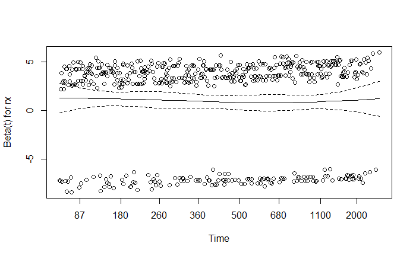

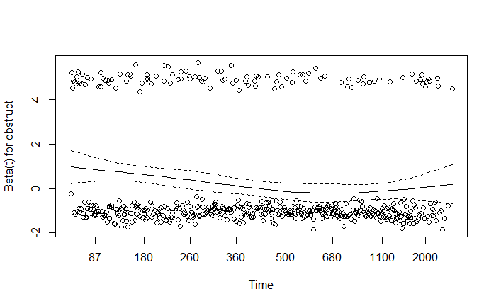

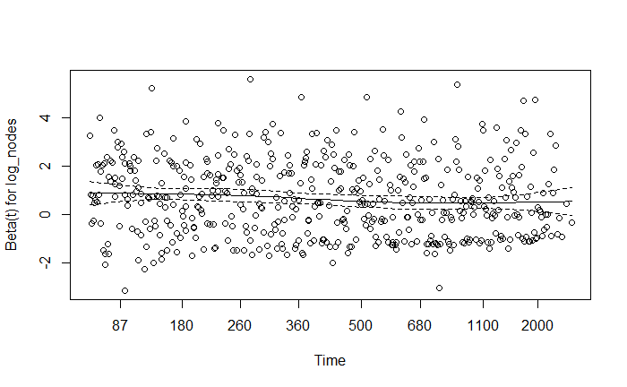

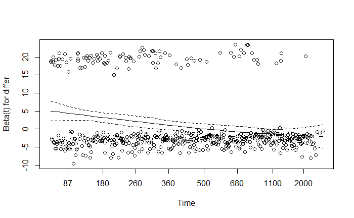

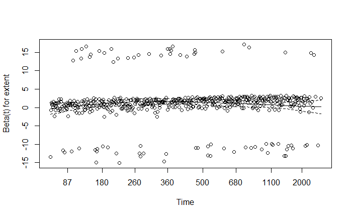

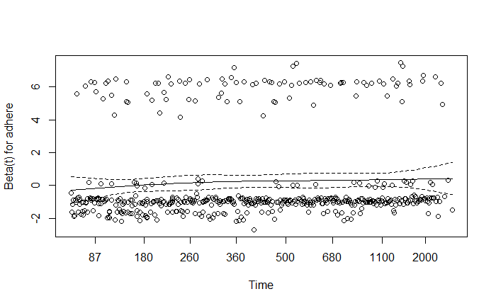

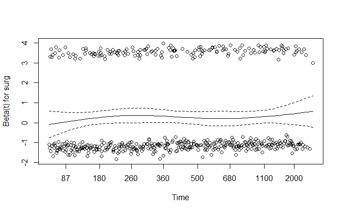

```r
plot(ph_test)
```

## Proportional Hazards Assumption Violation

### Global Test

- **p = 5.0e-06**: Overall, the model violates proportional hazards.

### Covariates with p < 0.05 in PH Test:

- **obstruct** (p = 0.0070)
- **log_nodes** (p = 0.0073)
- **differ** (p = 1.1e-06)

This means obstruct, log_nodes, and differ show evidence that their hazard ratios change over time. The plotted scaled Schoenfeld residuals (like for log_nodes or differ) might show a non-horizontal trend.

### Interpretation

- The PH assumption is violated for these covariates.

### Potential Solutions:

- **Stratify on obstruct or differ**: If they’re key categorical variables.
- **Time-varying approach for log_nodes**: If it strongly changes over time.
- **Check if recoding or grouping factor levels helps**: Simplifying categories might reduce violations.
- **Evaluate whether you still want to keep them in the model**: If the violation is moderate, consider the trade-offs.

## Visual Inspection of Residual Plots

### Schoenfeld Residual Plots for Each Variable

#### obstruct

- **Observation**: Some drift over time.
- **Interpretation**: This aligns with the p = 0.007 in the PH test.

#### log_nodes

- **Observation**: Slight slope or curvature in the fitted line.
- **Interpretation**: This might be mild or moderate.

#### differ

- **Observation**: Possibly a noticeable downward trend.
- **Interpretation**: Indicates time-dependent effects.

#### extent

- **Observation**: Fairly horizontal.
- **Interpretation**: No big violation.

#### adhere, surg

- **Observation**: Also appear fairly stable.
- **Interpretation**: No major PH violations.

### Summary

- **rx**: No major PH violation.
- **obstruct**: Shows some drift, indicating a potential violation.
- **log_nodes**: Mild to moderate violation.
- **differ**: Indicates time-dependent effects.
- **extent, adhere, surg**: No significant violations.

## Check Linearity for Numeric Variables

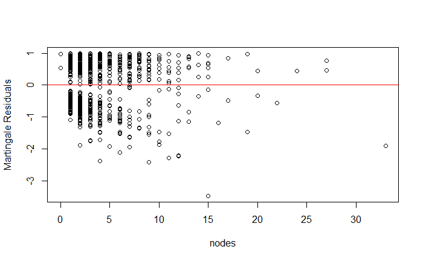

```r
resid_mart <- residuals(cox_model, type = "martingale")

# For 'nodes'
plot(colon_any_event$nodes, resid_mart,
     xlab = "nodes", ylab = "Martingale Residuals")
abline(h = 0, col = "red")
```

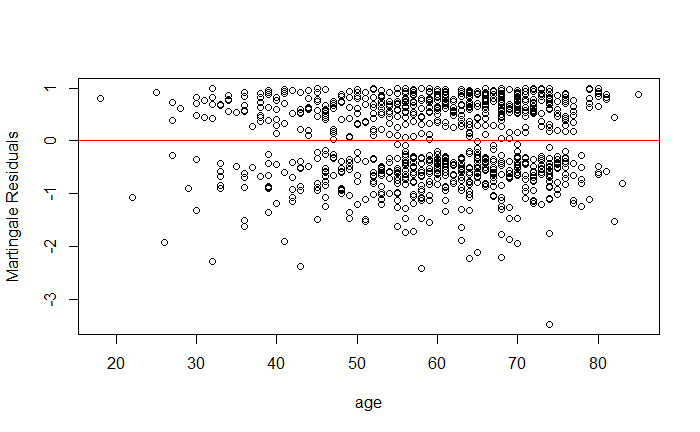

```r
# For 'age'
plot(colon_any_event$age, resid_mart,
     xlab = "age", ylab = "Martingale Residuals")
abline(h = 0, col = "red")
```

## Nodes Plot

### Observations:

- Many points are near 0 for node counts under ~10, then some outliers for high node counts (20–30+).
- Possibly a mild negative slope for low node values, but the main cluster is near 0.
- High node counts (above ~10) are relatively sparse but some negative residuals.

### Interpretation:

- The overall pattern doesn’t show a strong curve, but there is a cluster effect from so many low node counts.
- we’ve already log-transformed nodes (log_nodes), which typically helps with the skew. This plot suggests it’s mostly okay, though you have a few outliers at high node counts.
- No glaring “U-shape” or strong departure from linearity is evident. The log transform is likely addressing the skew effectively.

## Age Plot

### Interpretation:

- No major violation of linearity for age. A gentle slope might exist, but it’s not pronounced.
- If clinically you suspect age might have a threshold effect (e.g., <50 vs. >70), you could explore a piecewise approach. But from this plot, age seems reasonably linear.

## Evaluate Model Performance (Harrell’s C-Index)

```r
# Suppose cox_model is  final model
summary(cox_model)$concordance
```

```
         C      se(C)
0.67242914 0.01173447
```

## Alternative: survcomp or pec Packages

```r
library(survcomp)
# x is your predicted risk from the Cox model (e.g., linear predictor)
x <- predict(cox_model, type = "lp")
# Surv object
S <- with(colon_any_event, Surv(time, status))

cindex_result <- concordance.index(x, surv.time = S[,1], surv.event = S[,2],
                                   method = "noether")
cindex_result$c.index
```

```
[1] 0.6734403
```

```r
cindex_result$lower
```

```
[1] 0.6504475
```

```r
cindex_result$upper
```

```
[1] 0.6964331
```

## Perform Cross-Validation or Bootstrapping

Bootstrapping for Robustness One common approach is to bootstrap the dataset multiple times and refit the Cox model to estimate the variability of coefficients and the C-index. Here’s a simplified example using the boot package:

```r
# install.packages("boot")
library(boot)
library(survival)

# 1) Define a function that fits the Cox model and returns the C-index
cox_boot <- function(data, indices) {
  d <- data[indices, ]  # bootstrap sample
  fit <- coxph(Surv(time, status) ~ rx + log_nodes + differ + extent + adhere + surg,
               data = d)
  # Return the C-index from summary
  return(summary(fit)$concordance[1])
}

# 2) Run boot
set.seed(123)
boot_res <- boot(data = colon_any_event, statistic = cox_boot, R = 1000)
# R=1000 bootstrap replications

# 3) Inspect results
boot_res
```

```
ORDINARY NONPARAMETRIC BOOTSTRAP


Call:
boot(data = colon_any_event, statistic = cox_boot, R = 1000)


Bootstrap Statistics :
     original      bias    std. error
t1* 0.6699443 0.002688992  0.01195667
```

```r
# 't' contains the bootstrap estimates of C-index
# you can compute mean, sd, etc.

mean(boot_res$t)   # average C-index across bootstraps
```

```
[1] 0.6726333
```

```r
sd(boot_res$t)     # standard deviation
```

```
[1] 0.01195667
```

## Cross-Validation Approach

we could do k-fold cross-validation (e.g., caret or cvTools) to split data into folds, train on k-1 folds, and test on the remaining fold. Then compute the C-index or partial log-likelihood on the test fold. Summarize across folds for an estimate of out-of-sample performance.

```r
cox_cv_cindex <- function(data, formula, k = 5, seed = 123) {
  set.seed(seed)

  n <- nrow(data)
  # Randomly assign each row to a fold (1..k)
  folds <- sample(rep(1:k, length.out = n))

  cindex_values <- numeric(k)  # store c-index for each fold

  for (i in 1:k) {
    # Split into training vs. test
    train_data <- data[folds != i, ]
    test_data  <- data[folds == i, ]

    # Fit Cox model on training
    fit <- coxph(formula, data = train_data)

    # Predict linear predictor (risk score) on test
    lp_test <- predict(fit, newdata = test_data, type = "lp")

    # Compute C-index for test set
    # Survcomp expects vectors: times, events, and predicted scores
    cindex_result <- concordance.index(
      x          = lp_test,                    # predicted risk
      surv.time  = test_data$time,             # actual survival time
      surv.event = test_data$status,           # actual event
      method     = "noether"                   # or "uno", "harrell", etc.
    )

    cindex_values[i] <- cindex_result$c.index
  }

  # Return average C-index and all fold values
  list(
    mean_cindex = mean(cindex_values),
    sd_cindex   = sd(cindex_values),
    cindex_each_fold = cindex_values
  )
}
```

```r
# Define your final formula
cox_formula <- Surv(time, status) ~ rx + log_nodes + differ + extent + adhere + surg

# Run 5-fold CV
cv_results <- cox_cv_cindex(data = colon_any_event, formula = cox_formula, k = 5, seed = 123)

cv_results$mean_cindex
```

```
[1] 0.6582201
```

```r
cv_results$sd_cindex
```

```
[1] 0.0317165
```

```r
cv_results$cindex_each_fold
```

```
[1] 0.6638451 0.6514017 0.6302998 0.7098058 0.6357483
```

## 1. In-Sample C-Index from summary(cox_model)

**Value:** ~0.6724 (SE ~0.0117).

**Interpretation:** On your full dataset, the model can correctly rank pairs of patients ~67% of the time. This is a moderate level of discrimination, typical in many clinical models.

## 2. C-Index via survcomp

**Value:** ~0.6734 (95% CI: 0.6504–0.6964).

**Interpretation:** This matches closely with the in-sample summary. The confidence interval indicates you can be fairly confident the true c-index lies in the ~0.65–0.70 range.

## 3. Bootstrapped C-Index

**Value:** ~0.6699 (bias ~0.0027, std. error ~0.012).

**Interpretation:** When you resample (with replacement) 1000 times, the average c-index is ~0.67, reinforcing that your model’s discrimination is stable and not the product of random chance. The std. error is ~0.012, consistent with the original SE ~0.0117.

## 5. Overall Conclusions

- **Consistent Performance:** All methods (in-sample, survcomp, bootstrapping, cross-validation) converge around 0.66–0.67 for the c-index.
- **Moderate Discrimination:** A c-index in the mid-0.60s is common in medical prognostic models, meaning the model is useful but not perfect.
- **Model Stability:**
  - Bootstrapping shows minimal bias and an SE ~0.012, so the estimate is stable.
  - Cross-Validation c-index is only slightly lower than in-sample, indicating limited overfitting.
- **Practical Interpretation:** Your Time to Any Event Cox model ranks patients’ risk in a moderate way. In a clinical context, this can still provide valuable prognostic insight, but the model is not extremely high in discrimination. ################################################################################

## Interpret Model Coefficients and Survival Curves

```r
summary(cox_model)
```

```
Call:
coxph(formula = Surv(time, status) ~ rx + obstruct + log_nodes +
    differ + extent + adhere + surg, data = colon_any_event)

  n= 929, number of events= 506

                     coef exp(coef) se(coef)      z Pr(>|z|)
rxLev            -0.05076   0.95051  0.10463 -0.485  0.62760
rxLev+5FU        -0.48112   0.61809  0.11363 -4.234 2.29e-05 ***
obstructYes       0.21000   1.23368  0.10950  1.918  0.05513 .
log_nodes         0.64920   1.91402  0.07047  9.213  < 2e-16 ***
differModerate    0.01230   1.01238  0.15810  0.078  0.93798
differPoor        0.30329   1.35430  0.18410  1.647  0.09947 .
extentMuscle      0.05354   1.05500  0.44028  0.122  0.90321
extentSerosa      0.52862   1.69660  0.41436  1.276  0.20204
extentContiguous  1.05941   2.88467  0.45077  2.350  0.01876 *
adhereYes         0.18430   1.20237  0.12147  1.517  0.12923
surgLong          0.26847   1.30796  0.09718  2.763  0.00573 **
---
Signif. codes:  0 ‘***’ 0.001 ‘**’ 0.01 ‘*’ 0.05 ‘.’ 0.1 ‘ ’ 1

                 exp(coef) exp(-coef) lower .95 upper .95
rxLev               0.9505     1.0521    0.7743    1.1669
rxLev+5FU           0.6181     1.6179    0.4947    0.7723
obstructYes         1.2337     0.8106    0.9954    1.5290
log_nodes           1.9140     0.5225    1.6671    2.1975
differModerate      1.0124     0.9878    0.7426    1.3801
differPoor          1.3543     0.7384    0.9441    1.9428
extentMuscle        1.0550     0.9479    0.4451    2.5005
extentSerosa        1.6966     0.5894    0.7531    3.8219
extentContiguous    2.8847     0.3467    1.1923    6.9790
adhereYes           1.2024     0.8317    0.9476    1.5256
surgLong            1.3080     0.7646    1.0811    1.5824

Concordance= 0.672  (se = 0.012 )
Likelihood ratio test= 157.5  on 11 df,   p=<2e-16
Wald test            = 162.6  on 11 df,   p=<2e-16
Score (logrank) test = 168.9  on 11 df,   p=<2e-16
```

## Covariate-by-Covariate Interpretation

### 1. rxLev

**HR = 0.9505, p = 0.628**  
Not significantly different from 1. This suggests Lev alone is not significantly better or worse than the reference treatment (likely rx=Obs) for preventing the event.

### 2. rxLev+5FU

**HR = 0.6181, p = 2.29e-05 (highly significant)**  
Interpreted as ~38% reduction in hazard relative to the reference group (Obs).  
In plain language: “Patients on Lev+5FU have significantly lower risk (by ~38%) than those on the reference treatment.”

### 3. obstructYes

**HR = 1.2337, p = 0.055 (borderline significance)**  
Suggests a 23% increase in hazard for patients with obstruction vs. those without, but only borderline significant (p ~ 0.055).  
In plain language: “Having an obstructed colon might slightly raise the risk of recurrence/death, but the evidence is borderline.”

### 4. log_nodes

**HR = 1.9140, p < 2e-16 (very highly significant)**
A 1-unit increase in log(nodes+1) nearly doubles the hazard.
In simpler terms: “If (nodes+1) goes up by a factor of
$$e^1 = 2.718$$
, hazard almost doubles.”
In plain language: “The number of positive lymph nodes is a strong predictor—more nodes means a substantially higher risk.”

### 5. differModerate

**HR = 1.0124, p = 0.938**  
No significant difference from the reference (likely differ=Well).  
“Moderate differentiation” doesn’t show a clear effect vs. well-differentiated tumors.

### 6. differPoor

**HR = 1.3543, p = 0.099 (borderline significance)**  
Suggests a ~35% increase in hazard vs. well-differentiated, but p ~ 0.10 is borderline.  
In plain language: “Poorly differentiated tumors may raise risk, but it’s not firmly significant.”

### 7. extentMuscle

**HR = 1.0550, p = 0.903**  
Not significant. Minimal difference from reference category (likely Submucosa).

### 8. extentSerosa

**HR = 1.6966, p = 0.202**  
Suggests ~70% higher hazard, but p=0.20 is not significant. No strong evidence that “Serosa” is worse than the reference category.

### 9. extentContiguous

**HR = 2.8847, p = 0.0188 (significant)**  
~2.9x hazard vs. the reference.  
In plain language: “Tumor extending to contiguous structures significantly increases the risk (almost triple).”

### 10. adhereYes

**HR = 1.2024, p = 0.129**  
Not significant (p=0.13). Possibly ~20% higher hazard, but not statistically confirmed.

### 11. surgLong

**HR = 1.3080, p = 0.0057 (significant)**  
~31% higher hazard if surgery-to-registration interval is “Long” vs. “Short.”  
In plain language: “Patients who had a longer gap between surgery and registration face a higher risk.”

## Overall Model Summary

- **Concordance (C-index) ~ 0.672:** The model’s discrimination is moderate (can rank patients’ risk ~67% of the time correctly).
- **Likelihood Ratio / Wald / Score tests:** All highly significant (p < 2e-16), meaning the model overall is very unlikely to be random

## Visualizing Survival Curves from a Cox Model

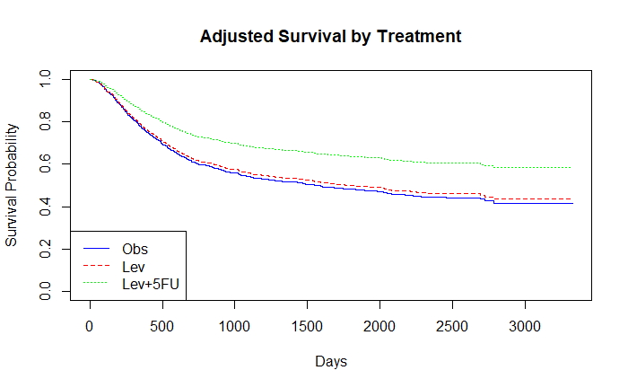

```r
# Example "typical" values for other covariates:
newdata_rx <- data.frame(
  rx = c("Obs", "Lev", "Lev+5FU"),
  obstruct = "No",
  log_nodes = mean(colon_any_event$log_nodes, na.rm=TRUE),
  differ = "Moderate",
  extent = "Serosa",
  adhere = "No",
  surg = "Short"
)

fit_surv <- survfit(cox_model, newdata = newdata_rx)

plot(fit_surv, col=c("blue","red","green"), lty=1:3,
     xlab="Days", ylab="Survival Probability",
     main="Adjusted Survival by Treatment")
legend("bottomleft", legend=c("Obs","Lev","Lev+5FU"),
       col=c("blue","red","green"), lty=1:3)
```

## Conclusion

### Data Preparation & Exploration

- We began by importing the Colon dataset, checking for missing values (notably in nodes and differ) and addressing them via imputation.
- Outlier checks (e.g., nodes, age) led to transformations (log_nodes) to handle skew.
- Basic Kaplan-Meier analyses indicated Lev+5FU was beneficial compared to Obs, while Lev alone was not clearly different.

### Cox PH Modeling

- Univariable tests identified rx=Lev+5FU, log_nodes, and certain tumor extent levels as strong predictors.
- The final Cox model included: Surv(time, status) ∼ rx + obstruct + log_nodes + differ + extent + adhere + surg.
- Key significant effects:
  - **rx=Lev+5FU:** Hazard ratio ~0.62 (p<0.0001), a ~38% hazard reduction vs. observation.
  - **log_nodes:** HR ~1.91, the strongest risk factor—more positive nodes drastically increase hazard.
  - **extentContiguous:** ~2.9x hazard vs. baseline.
  - **surgLong:** ~31% higher hazard vs. surgShort.

### Model Assumption Checks & Validation

- **PH Tests:** Showed potential violations for obstruct, log_nodes, differ, suggesting mild time-varying effects or need for stratification.
- **Performance:**
  - In-sample C-index: ~0.67, indicating moderate discrimination.
  - Bootstrapping: Confirmed stability with minimal bias and SE ~0.012.
  - 5-Fold Cross-Validation: Mean C-index ~0.66, close to in-sample, implying limited overfitting.

### Adjusted Survival Curves

- Visualizing survival by rx with other covariates at average levels showed a notably higher curve for Lev+5FU, confirming its protective effect.
- Lev alone tracked close to observation, matching the non-significant difference in hazard.

### Overall Findings

- **Lev+5FU** stands out as the most effective regimen in this dataset, significantly improving survival compared to observation or Lev alone.
- **Number of nodes (log_nodes)** remains the dominant risk factor, highlighting the critical prognostic role of lymph node involvement.
- The model offers moderate predictive power (C-index ~0.67), confirmed by bootstrapping and cross-validation.

### Practical Implication

Clinically, combining Lev+5FU post-surgery could lead to better outcomes, especially in patients with higher node counts or advanced tumor extent, although further prospective validation is advised.